# Synthetic Control Methods

## What the Diagnostics Caught

| Diagnostic | Good support | Poor support |
| --- | --- | --- |
| Pre-treatment RMSPE | Small relative to outcome scale | An order of magnitude larger, an immediate warning |
| Path plot | Lines overlap before treatment | Lines never align, visible without the truth |
| Gap plot | Flat at zero pre-treatment | Large pre-treatment swings |
| Estimated vs. true ATT | Close | Attenuated to roughly a sixth of the truth |

The point is not that SCM worked in one case and failed in the other. It is that **the failure was detectable from the pre-treatment period alone**, using only information available to any reader of the figures. That is the property that makes the method defensible, and it is why the diagnostics are not optional decoration.

# Classical SCM with `Synth`: Proposition 99

Now the real data. The `tidysynth` package ships the Abadie, Diamond, and Hainmueller panel: 39 states, 1970 to 2000, annual per-capita cigarette sales (Abadie, Diamond, and Hainmueller 2010).[^1]

## Data Requirements

The `Synth` package implements the classical estimator used in the foundational applications (Hainmueller and Diamond 2026). It expects long panel data, one row per unit-period.

| Variable | Role |
| --- | --- |
| Unit identifier | Numeric ID used by the optimizer |
| Unit name | Readable label for tables and plots |
| Time identifier | A consistently coded period variable |
| Outcome | The variable whose untreated path you want to estimate |
| Predictors | Pre-treatment covariates and outcome summaries |
| Treatment date | A design choice, not a column `Synth` infers |

Donors must be untreated throughout the analysis window and plausibly unaffected by the intervention. The published donor pool already excludes states that adopted their own large tobacco-control programs.

**R**

```r
# Local cache of tidysynth::smoking (see synthetic-control_files/data/PROVENANCE.md).
smoking <- read.csv("synthetic-control_files/data/smoking.csv")

smoking_df <- smoking |>
  mutate(state_id = as.numeric(factor(state))) |>
  as.data.frame()

ca_id <- unique(smoking_df$state_id[smoking_df$state == "California"])
donor_ids <- sort(setdiff(unique(smoking_df$state_id), ca_id))

cat("States:", length(unique(smoking_df$state)),
    "| California id:", ca_id, "| donors:", length(donor_ids),
    "| years:", paste(range(smoking_df$year), collapse = "-"), "\n")
```

```
States: 39 | California id: 3 | donors: 38 | years: 1970-2000
```

**Python**

```python
import pandas as pd
smoking = pd.read_csv("synthetic-control_files/data/smoking.csv")

# as.numeric(factor(state)): 1-based alphabetical codes (California -> 3)
smoking["state_id"] = pd.Categorical(smoking["state"]).codes + 1

ca_id = int(smoking.loc[smoking.state == "California", "state_id"].iloc[0])
donor_ids = sorted(set(smoking.state_id) - {ca_id})

print(f"States: {smoking.state.nunique()} | California id: {ca_id} | "
      f"donors: {len(donor_ids)} | "
      f"years: {smoking.year.min()}-{smoking.year.max()}")
```

```
States: 39 | California id: 3 | donors: 38 | years: 1970-2000
```

**Stata**

```stata
import delimited "synthetic-control_files/data/smoking.csv", clear
* R writes missing as "NA", so columns with gaps import as strings.
destring lnincome beer age15to24, replace force
encode state, gen(state_id)          // alphabetical, California -> 3
quietly summarize state_id if state == "California"
local ca = r(mean)
quietly levelsof state_id, local(ids)
local nstates : word count `ids'
local ndonors = `nstates' - 1
quietly summarize year
display "States: " `nstates' " | California id: " `ca' ///
        " | donors: " `ndonors' " | years: " r(min) "-" r(max)
```

```
(encoding automatically selected: ISO-8859-2)
(7 vars, 1,209 obs)

lnincome: contains nonnumeric characters; replaced as double
(195 missing values generated)
beer: contains nonnumeric characters; replaced as double
(663 missing values generated)
age15to24: contains nonnumeric characters; replaced as double
(390 missing values generated)








States: 39 | California id: 3 | donors: 38 | years: 1970-2000
```

## Fitting the Synthetic California

The specification follows the published analysis: income, retail price, and the share aged 15 to 24 averaged over 1980 to 1988, beer consumption over 1984 to 1988 (the years it is observed), and cigarette sales in 1975, 1980, and 1988.

**R**

```r
prep_ca <- dataprep(
  foo = smoking_df,
  predictors = c("lnincome", "retprice", "age15to24"),
  predictors.op = "mean",
  dependent = "cigsale",
  unit.variable = "state_id",
  unit.names.variable = "state",
  time.variable = "year",
  special.predictors = list(
    list("beer", 1984:1988, "mean"),
    list("cigsale", 1975, "mean"),
    list("cigsale", 1980, "mean"),
    list("cigsale", 1988, "mean")
  ),
  treatment.identifier = ca_id,
  controls.identifier = donor_ids,
  time.predictors.prior = 1980:1988,
  time.optimize.ssr = 1970:1988,
  time.plot = 1970:2000
)

invisible(capture.output(fit_ca <- synth(prep_ca)))
tabs_ca <- synth.tab(dataprep.res = prep_ca, synth.res = fit_ca)
```

**Python**

```python
from pysyncon import Dataprep, Synth

donors = [s for s in smoking.state.unique() if s != "California"]
dp_ca = Dataprep(
    foo=smoking, dependent="cigsale",
    unit_variable="state", time_variable="year",
    treatment_identifier="California", controls_identifier=donors,
    predictors=["lnincome", "retprice", "age15to24"], predictors_op="mean",
    time_predictors_prior=range(1980, 1989),
    special_predictors=[
        ("beer", range(1984, 1989), "mean"),
        ("cigsale", [1975], "mean"),
        ("cigsale", [1980], "mean"),
        ("cigsale", [1988], "mean"),
    ],
    time_optimize_ssr=range(1970, 1989),
)
synth_ca = Synth()
synth_ca.fit(dp_ca)   # silent fit; weights and gaps read out below
```

**Stata**

```stata
import delimited "synthetic-control_files/data/smoking.csv", clear
destring lnincome beer age15to24, replace force
encode state, gen(state_id)
tsset state_id year
quietly summarize state_id if state == "California"
* synth prints unit weights, predictor balance, and RMSPE in one table.
synth cigsale lnincome(1980(1)1988) retprice(1980(1)1988) age15to24(1980(1)1988) ///
      beer(1984(1)1988) cigsale(1975) cigsale(1980) cigsale(1988), ///
      trunit(`r(mean)') trperiod(1989) mspeperiod(1970(1)1988) ///
      resultsperiod(1970(1)2000)
```

```
(encoding automatically selected: ISO-8859-2)
(7 vars, 1,209 obs)

lnincome: contains nonnumeric characters; replaced as double
(195 missing values generated)
beer: contains nonnumeric characters; replaced as double
(663 missing values generated)
age15to24: contains nonnumeric characters; replaced as double
(390 missing values generated)



Panel variable: state_id (strongly balanced)
 Time variable: year, 1970 to 2000
         Delta: 1 unit


--------------------------------------------------------------------------------------------------------------------------------------------
Synthetic Control Method for Comparative Case Studies
--------------------------------------------------------------------------------------------------------------------------------------------

First Step: Data Setup
--------------------------------------------------------------------------------------------------------------------------------------------
--------------------------------------------------------------------------------------------------------------------------------------------
Data Setup successful
--------------------------------------------------------------------------------------------------------------------------------------------
                Treated Unit: California
               Control Units: Alabama, Arkansas, Colorado, Connecticut, Delaware, Georgia, Idaho, Illinois, Indiana, Iowa, Kansas, Kentucky,
                              Louisiana, Maine, Minnesota, Mississippi, Missouri, Montana, Nebraska, Nevada, New Hampshire, New Mexico,
                              North Carolina, North Dakota, Ohio, Oklahoma, Pennsylvania, Rhode Island, South Carolina, South Dakota,
                              Tennessee, Texas, Utah, Vermont, Virginia, West Virginia, Wisconsin, Wyoming
--------------------------------------------------------------------------------------------------------------------------------------------
          Dependent Variable: cigsale
  MSPE minimized for periods: 1970 1971 1972 1973 1974 1975 1976 1977 1978 1979 1980 1981 1982 1983 1984 1985 1986 1987 1988
Results obtained for periods: 1970 1971 1972 1973 1974 1975 1976 1977 1978 1979 1980 1981 1982 1983 1984 1985 1986 1987 1988 1989 1990 1991
                              1992 1993 1994 1995 1996 1997 1998 1999 2000
--------------------------------------------------------------------------------------------------------------------------------------------
                  Predictors: lnincome(1980(1)1988) retprice(1980(1)1988) age15to24(1980(1)1988) beer(1984(1)1988) cigsale(1975)
                              cigsale(1980) cigsale(1988)
--------------------------------------------------------------------------------------------------------------------------------------------
```

[output cut: 80 more lines]

[output not shown]

Read the weights before the gap plot.

**R**

```r
w_ca <- tabs_ca$tab.w
w_ca[w_ca$w.weights > 0.001, ] |>
  arrange(desc(w.weights))
```

```
   w.weights  unit.names unit.numbers
34     0.343        Utah           34
21     0.236      Nevada           21
19     0.182     Montana           19
4      0.175    Colorado            4
5      0.062 Connecticut            5
```

**Python**

```python
w_py = synth_ca.weights().sort_values(ascending=False)
print(w_py[w_py > 0.001].round(4).to_string())
```

```
Colorado       0.625
Connecticut    0.273
Utah           0.101
```

**Stata**

```stata
import delimited "synthetic-control_files/data/smoking.csv", clear
destring lnincome beer age15to24, replace force
encode state, gen(state_id)
tsset state_id year
quietly summarize state_id if state == "California"
quietly synth cigsale lnincome(1980(1)1988) retprice(1980(1)1988) ///
      age15to24(1980(1)1988) beer(1984(1)1988) cigsale(1975) cigsale(1980) ///
      cigsale(1988), trunit(`r(mean)') trperiod(1989) mspeperiod(1970(1)1988)
matrix W = e(W_weights)          // column 1 = weight, column 2 = unit id
matrix list W, format(%6.4f)
```

```
(encoding automatically selected: ISO-8859-2)
(7 vars, 1,209 obs)

lnincome: contains nonnumeric characters; replaced as double
(195 missing values generated)
beer: contains nonnumeric characters; replaced as double
(663 missing values generated)
age15to24: contains nonnumeric characters; replaced as double
(390 missing values generated)



Panel variable: state_id (strongly balanced)
 Time variable: year, 1970 to 2000
         Delta: 1 unit





W[38,2]
              _Co_Number   _W_Weight
     Alabama      1.0000      0.0000
    Arkansas      2.0000      0.0000
    Colorado      4.0000      0.3560
 Connecticut      5.0000      0.0830
    Delaware      6.0000      0.0000
     Georgia      7.0000      0.0000
       Idaho      8.0000      0.0000
    Illinois      9.0000      0.0000
     Indiana     10.0000      0.0000
        Iowa     11.0000      0.0000
      Kansas     12.0000      0.0000
    Kentucky     13.0000      0.0000
   Louisiana     14.0000      0.0000
       Maine     15.0000      0.0000
   Minnesota     16.0000      0.0000
 Mississippi     17.0000      0.0000
    Missouri     18.0000      0.0000
     Montana     19.0000      0.0000
```

[output cut: 23 more lines]

[output not shown]

**The three implementations agree on the effect, not the weights**

All three fit the *same* specification, and all three imply a similar Proposition 99 effect (mean post-1988 gap near $-18$ to $-20$ packs, and roughly $-25$ by 2000). But the **donor weights differ**: R leans on Utah and Nevada, `pysyncon` on Colorado and Connecticut, Stata’s `synth` on a Colorado/Utah/Nevada blend. This is not a bug; it is the $V/W$ non-uniqueness discussed above (Klößner et al. 2018). The estimand is robust across solvers; the exact synthetic unit is not. Report which implementation and settings produced your weights.

Synthetic California is a blend of five states, with Utah and Nevada carrying the most weight. Whether that is substantively sensible is a question for a reader who knows something about tobacco markets, which is exactly the sort of judgment the method makes possible.

**R**

```r
tabs_ca$tab.pred
```

```
                       Treated Synthetic Sample Mean
lnincome                10.077     9.859       9.829
retprice                89.422    89.318      87.266
age15to24                0.174     0.174       0.173
special.beer.1984.1988  24.280    24.095      23.655
special.cigsale.1975   127.100   126.897     136.932
special.cigsale.1980   120.200   120.248     138.089
special.cigsale.1988    90.100    91.432     113.824
```

**Python**

```python
# pysyncon prints predictor balance (treated vs synthetic vs donor sample) via summary().
synth_ca.summary()
```

```
                       V  treated  synthetic  sample mean
lnincome           0.077   10.077     10.009        9.829
retprice           0.120   89.422     89.016       87.266
age15to24          0.218    0.174      0.172        0.173
special.1.beer     0.017   24.280     22.694       23.655
special.2.cigsale  0.150  127.100    119.724      136.932
special.3.cigsale  0.246  120.200    121.756      138.089
special.4.cigsale  0.172   90.100     93.382      113.824
```

**Stata**

```stata
import delimited "synthetic-control_files/data/smoking.csv", clear
destring lnincome beer age15to24, replace force
encode state, gen(state_id)
tsset state_id year
quietly summarize state_id if state == "California"
quietly synth cigsale lnincome(1980(1)1988) retprice(1980(1)1988) ///
      age15to24(1980(1)1988) beer(1984(1)1988) cigsale(1975) cigsale(1980) ///
      cigsale(1988), trunit(`r(mean)') trperiod(1989) mspeperiod(1970(1)1988)
matrix list e(X_balance)   // treated, synthetic, and donor-average predictors
```

```
(encoding automatically selected: ISO-8859-2)
(7 vars, 1,209 obs)

lnincome: contains nonnumeric characters; replaced as double
(195 missing values generated)
beer: contains nonnumeric characters; replaced as double
(663 missing values generated)
age15to24: contains nonnumeric characters; replaced as double
(390 missing values generated)



Panel variable: state_id (strongly balanced)
 Time variable: year, 1970 to 2000
         Delta: 1 unit




e(X_balance)[7,2]
                 Treated  Synthetic
 lninco~1988)  10.076559  9.9047732
 retpri~1988)  89.422223  89.001278
 age15t~1988)  .17353238  .17538896
 beer(1~1988)      24.28   23.26454
cigsale(1975)      127.1   126.3862
cigsale(1980)      120.2   120.7221
cigsale(1988)  90.099998  92.088298

counter | pri_inf  | dual_inf  | pri_obj   | dual_obj  | sigfig | alpha  | nu
----------------------------------------------------------------------------------
      0 | 8.29e+01 | 6.80e-06 | -1.36e+01 | -3.94e+02 |  0.000 | 0.0000 | 1.00e+02
      1 | 5.05e-01 | 4.14e-08 | -1.36e+01 | -7.03e+02 |  0.000 | 0.9939 | 3.06e-05
      2 | 2.87e-03 | 2.35e-10 | -1.36e+01 | -2.90e+01 |  0.000 | 0.9943 | 2.72e-06
      3 | 1.63e-04 | 1.33e-11 | -1.36e+01 | -1.45e+01 |  1.220 | 0.9433 | 5.50e-06
      4 | 1.60e-05 | 1.32e-12 | -1.36e+01 | -1.38e+01 |  2.024 | 0.9013 | 9.47e-07
      5 | 8.35e-06 | 6.85e-13 | -1.36e+01 | -1.37e+01 |  2.305 | 0.4792 | 4.50e-06
      6 | 2.37e-06 | 1.94e-13 | -1.36e+01 | -1.37e+01 |  2.833 | 0.7163 | 6.69e-07
      7 | 7.27e-07 | 5.96e-14 | -1.36e+01 | -1.37e+01 |  3.334 | 0.6933 | 2.33e-07
      8 | 1.61e-07 | 1.32e-14 | -1.36e+01 | -1.36e+01 |  3.924 | 0.7790 | 3.75e-08
      9 | 3.88e-09 | 3.18e-16 | -1.36e+01 | -1.36e+01 |  5.302 | 0.9758 | 1.11e-10
     10 | 1.99e-11 | 2.13e-18 | -1.36e+01 | -1.36e+01 |  7.563 | 0.9949 | 2.09e-13
     11 | 9.92e-14 | 1.22e-18 | -1.36e+01 | -1.36e+01 |  9.861 | 0.9950 | 1.09e-15
     12 | 8.56e-16 | 1.74e-18 | -1.36e+01 | -1.36e+01 | 12.158 | 0.9950 | 5.49e-18
----------------------------------------------------------------------------------
optimization converged
```

Predictor balance improves markedly on the raw donor average, most visibly for the pre-treatment sales figures.

**R**

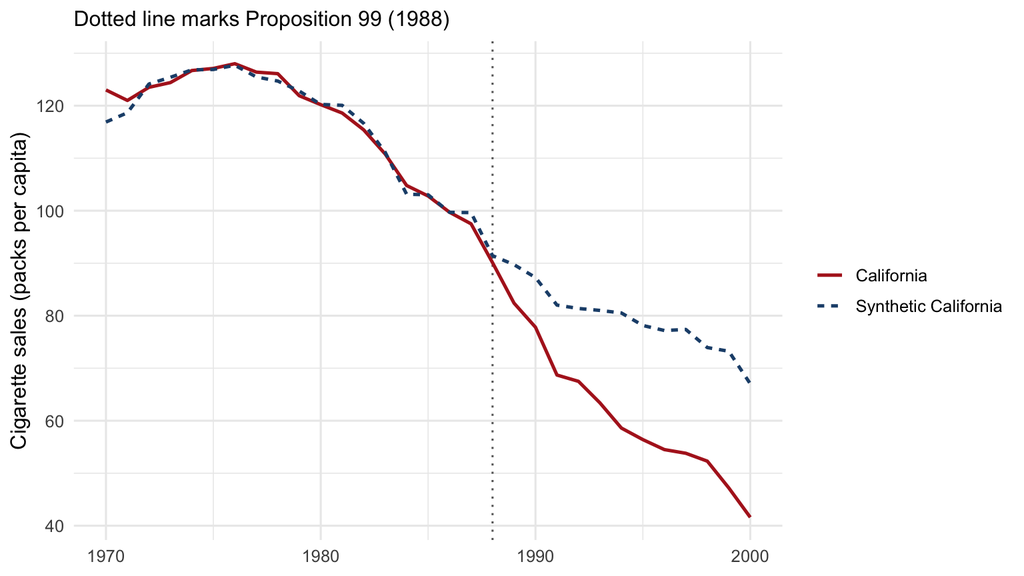

California and synthetic California, 1970-2000. The series track closely for the nineteen pre-treatment years, then diverge after Proposition 99.

```r
years_ca <- as.numeric(rownames(prep_ca$Y1plot))
synth_ca <- as.vector(prep_ca$Y0plot %*% fit_ca$solution.w)
obs_ca <- as.vector(prep_ca$Y1plot)
gap_ca <- obs_ca - synth_ca

data.frame(year = years_ca, California = obs_ca,
           `Synthetic California` = synth_ca, check.names = FALSE) |>
  pivot_longer(-year, names_to = "series", values_to = "cigsale") |>
  ggplot(aes(year, cigsale, colour = series, linetype = series)) +
  geom_vline(xintercept = 1988, linetype = "dotted", colour = "grey40") +
  geom_line(linewidth = 0.9) +
  scale_colour_manual(values = setNames(c(PAL[["treated"]], PAL[["synth"]]),
                                        c("California", "Synthetic California"))) +
  labs(x = NULL, y = "Cigarette sales (packs per capita)",
       colour = NULL, linetype = NULL,
       subtitle = "Dotted line marks Proposition 99 (1988)")
```

**Python**

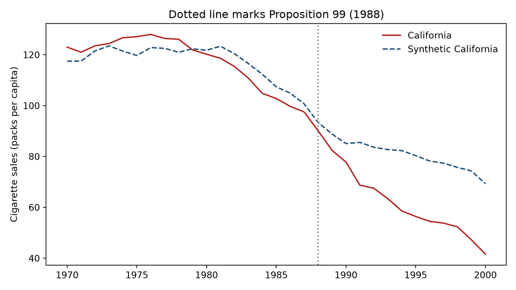

```python
wide_ca = smoking.pivot(index="year", columns="state", values="cigsale").sort_index()
synth_path = wide_ca[donors].values @ np.asarray(synth_ca.W)
obs_path = wide_ca["California"].values
years = wide_ca.index.values
gap_ca = obs_path - synth_path

fig, ax = plt.subplots(figsize=(8, 4.5))
ax.plot(years, obs_path, color="#B22222", label="California")
ax.plot(years, synth_path, color="#1F4E79", linestyle="--", label="Synthetic California")
ax.axvline(1988, color="grey", linestyle=":")
ax.set_ylabel("Cigarette sales (packs per capita)")
ax.set_title("Dotted line marks Proposition 99 (1988)")
ax.legend(frameon=False)
plt.tight_layout()
plt.show()
```

**Stata**

```stata
import delimited "synthetic-control_files/data/smoking.csv", clear
destring lnincome beer age15to24, replace force
encode state, gen(state_id)
tsset state_id year
quietly summarize state_id if state == "California"
quietly synth cigsale lnincome(1980(1)1988) retprice(1980(1)1988) ///
      age15to24(1980(1)1988) beer(1984(1)1988) cigsale(1975) cigsale(1980) ///
      cigsale(1988), trunit(`r(mean)') trperiod(1989) mspeperiod(1970(1)1988) ///
      resultsperiod(1970(1)2000) keep("synthetic-control_files/stata/_ca_out", replace)
use "synthetic-control_files/stata/_ca_out", clear
twoway (line _Y_treated _time, lcolor("178 34 34")) ///
       (line _Y_synthetic _time, lcolor("31 78 121") lpattern(dash)), ///
       xline(1988, lpattern(dot)) ytitle("Cigarette sales (packs per capita)") ///
       legend(order(1 "California" 2 "Synthetic California")) xtitle("")
quietly graph export "sc_figs/prop99-paths-stata.svg", replace width(1600)
```

[output not shown]

[figure not shown]

**R**

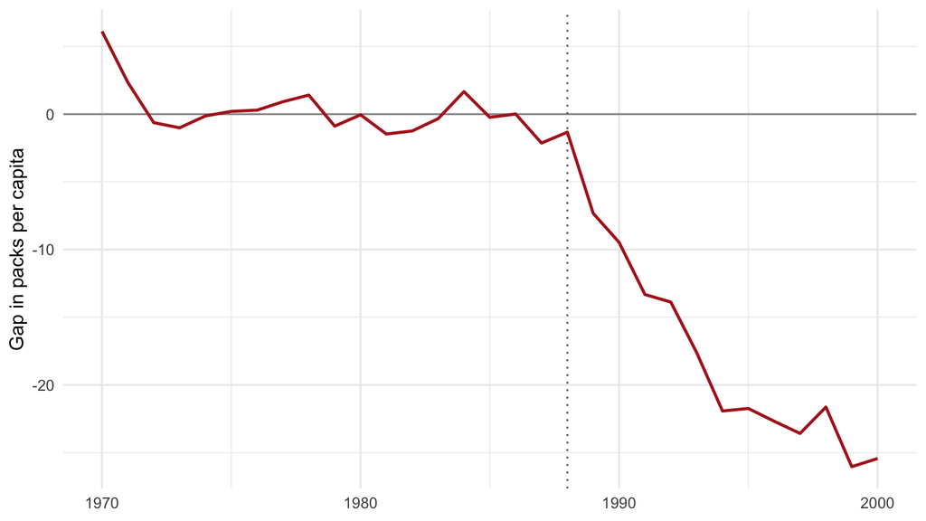

Estimated per-capita effect of Proposition 99, measured as California minus synthetic California.

```r
pre_ca <- years_ca <= 1988

data.frame(year = years_ca, gap = gap_ca) |>
  ggplot(aes(year, gap)) +
  geom_hline(yintercept = 0, colour = "grey60") +
  geom_vline(xintercept = 1988, linetype = "dotted", colour = "grey40") +
  geom_line(colour = PAL[["treated"]], linewidth = 0.9) +
  labs(x = NULL, y = "Gap in packs per capita")
```

```r
cat("Pre-treatment RMSPE:", round(sqrt(mean(gap_ca[pre_ca]^2)), 3), "\n")
```

```
Pre-treatment RMSPE: 1.791
```

```r
cat("Mean post-1988 gap :", round(mean(gap_ca[!pre_ca]), 2), "packs\n")
```

```
Mean post-1988 gap : -18.72 packs
```

```r
cat("Gap in 2000        :", round(gap_ca[years_ca == 2000], 2), "packs\n")
```

```
Gap in 2000        : -25.43 packs
```

**Python**

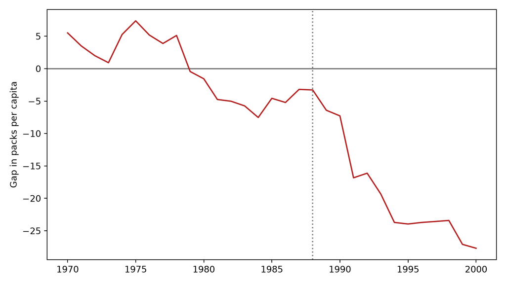

```python
pre = years <= 1988
fig, ax = plt.subplots(figsize=(8, 4.5))
ax.axhline(0, color="grey")
ax.axvline(1988, color="grey", linestyle=":")
ax.plot(years, gap_ca, color="#B22222")
ax.set_ylabel("Gap in packs per capita")
plt.tight_layout()
plt.show()
```

```python
print(f"Pre-treatment RMSPE: {round(np.sqrt(np.mean(gap_ca[pre]**2)), 3)}")
```

```
Pre-treatment RMSPE: 4.628
```

```python
print(f"Mean post-1988 gap : {round(gap_ca[~pre].mean(), 2)} packs")
```

```
Mean post-1988 gap : -19.92 packs
```

```python
print(f"Gap in 2000        : {round(gap_ca[years == 2000][0], 2)} packs")
```

```
Gap in 2000        : -27.69 packs
```

**Stata**

```stata
use "synthetic-control_files/stata/_ca_out", clear                       // saved by the paths block
gen gap = _Y_treated - _Y_synthetic
twoway line gap _time, yline(0) xline(1988, lpattern(dot)) ///
       lcolor("178 34 34") ytitle("Gap in packs per capita") xtitle("")
gen g2 = gap^2 if _time <= 1988
quietly summarize g2
display "Pre-treatment RMSPE: " %6.3f sqrt(r(mean))
quietly summarize gap if _time > 1988
display "Mean post-1988 gap : " %6.2f r(mean) " packs"
quietly summarize gap if _time == 2000
display "Gap in 2000        : " %6.2f r(mean) " packs"
quietly graph export "sc_figs/prop99-gap-stata.svg", replace width(1600)
```

```
(7 missing values generated)


(19 missing values generated)


Pre-treatment RMSPE:  2.037


Mean post-1988 gap : -17.96 packs


Gap in 2000        : -24.54 packs
```

[figure not shown]

The pre-treatment RMSPE is small on a scale where sales run above 100 packs per capita, and the estimated effect grows over time, reaching roughly 25 fewer packs per capita by 2000. That growth pattern is itself substantively meaningful: a tax-plus-campaign intervention would be expected to accumulate, not to jump once and flatten.

`Synth` also ships quick base-R versions of these two figures, `path.plot()` and `gaps.plot()`, which take the same `synth.res` and `dataprep.res` objects.

## What to Check, and in What Order

1. **Pre-treatment path:** does the synthetic control track the treated unit before treatment?
2. **Donor weights:** which units are carrying the comparison?
3. **Predictor balance:** does the synthetic control improve on the raw donor average?
4. **Post-treatment gap:** how large and persistent is the divergence?
5. **Placebos:** does the treated gap look unusual relative to fake-treated donors?
6. **Sensitivity:** does the conclusion survive reasonable donor exclusions and leave-one-out checks?

If item one fails, item four is not worth reading.

**The Optimizer’s Answer Is Not Always Unique**

`synth()` solves the $V$-weighted minimization by numerical optimization, and the nested optimization used to choose $V$ is not guaranteed to have a unique solution. Klößner, Kaul, Pfeifer, and Schieler show that reproductions of the same application can land on different predictor weights, and therefore different donor weights, across software and settings that all claim to implement the same method (Klößner et al. 2018). The weights above are close to, but not identical to, the published figures for exactly this reason. Report the software, version, and optimization settings, and revisit the fit if a small settings change moves the conclusion.

`Synth` is not the only implementation. `tidysynth` reimplements the same method with a pipeline interface that some readers find easier to adapt (Dunford 2025).

# Generalizing Synthetic Control

Classical SCM assumes a specific and rather restrictive world: one treated unit, one treatment date, treatment that never switches off. Most panel data are not that tidy.

## Where the Classical Design Runs Out

| Complication | Why classical SCM strains |
| --- | --- |
| **Several treated units** | You could fit a separate synthetic control per treated unit, but there is no single estimand, no shared uncertainty statement, and donor pools overlap. |
| **Staggered adoption** | Units treated at different dates means “the pre-period” is unit-specific, and a unit treated late is a valid donor early and an invalid one later. |
| **Treatment reversal** | If treatment switches off, post-treatment periods are not uniformly treated, and the “after” window stops being well defined. |
| **Missing observations** | The optimizer needs a balanced matrix of pre-treatment outcomes; holes break it. |
| **Covariate-dependent trends** | Convex weights on outcome paths may not absorb a trend driven by a covariate. |

The unifying fix is to stop thinking about *weighting donors* and start thinking about *imputing the missing potential outcome* from a model fitted on the untreated observations.

## The Factor-Model View

Write untreated outcomes as an interactive fixed-effects model:

$$Y_{it}(0) = \mu + \alpha_i + \xi_t + \lambda_i' f_t + \varepsilon_{it},$$

where $\alpha_i$ is a unit effect, $\xi_t$ a common time effect, $f_t$ a vector of $r$ latent time-varying factors, and $\lambda_i$ the unit’s loadings on them. Additive two-way fixed effects are the special case $r = 0$; parallel trends is what that assumption buys you.

The generalized synthetic control estimator proceeds in three steps (Xu 2017):

1. Fit the factor model on **untreated observations only**, estimating $f_t$ and each unit’s $\lambda_i$.
2. For a treated unit, estimate its loadings $\lambda_i$ from its **pre-treatment** periods.
3. Impute $\widehat{Y}_{it}(0)$ for treated periods and take the difference from what was observed.

This generalizes classical SCM rather than simply competing with it, though the two are not the same estimator and can disagree, as we show below. Classical SCM matches the pre-treatment path in order to implicitly match $\lambda_i$; the factor model estimates $\lambda_i$ directly. Because step 3 is an imputation, everything that broke above now works: multiple treated units simply give more imputations to average, staggered adoption means each unit has its own set of imputed periods, and reversal is handled because treated status is defined observation by observation rather than by a single date.

The `fect` package implements this family of counterfactual estimators, including the generalized synthetic control procedure (Xu et al. 2026).

| Setting | Starting point in `fect` |
| --- | --- |
| Few treated units; block or staggered adoption; no reversal; time components learned from never-treated donors | `method = "gsynth"` |
| Counterfactual imputation using not-yet-treated observations, including treatment reversal | `method = "ife"` |
| Standard additive fixed-effects counterfactual | `method = "fe"` |
| Matrix-completion formulation | `method = "mc"` |

The choice changes both the source of identifying variation and the uncertainty procedure.

## Recovering a Known Effect

`fect` ships a simulated panel generated from exactly this factor structure, including the true factors, the true loadings, and the true treatment effect, so we can check the estimator against ground truth.[^2]

**The generalized SCM estimator across languages**

R uses `fect`; Stata uses `fect` (same authors; R’s `method="gsynth"` is Stata’s `method("ife")`). The official Python port [`fect_python`](https://github.com/xuyiqing/fect_python) is an `rpy2` wrapper around R’s `fect`, but its import conflicts with this environment’s `rpy2` build, so the Python tabs below use a compact **native NumPy implementation** of the interactive fixed-effects estimator instead. It recovers the same known effect (about $5.5$ against a truth of $5.46$); it is not a full reimplementation of `fect` (no cross-validation search or bootstrap inference), which is why the R and Stata tabs remain the reference.

**R**

```r
# Local cache of fect::simgsynth (see synthetic-control_files/data/PROVENANCE.md).
simgsynth <- read.csv("synthetic-control_files/data/simgsynth.csv")

cat("Units:", length(unique(simgsynth$id)),
    "| periods:", length(unique(simgsynth$time)),
    "| treated observations:", sum(simgsynth$D == 1), "\n")
```

```
Units: 50 | periods: 30 | treated observations: 50
```

```r
cat("True ATT:", round(mean(simgsynth$eff[simgsynth$D == 1]), 3), "\n")
```

```
True ATT: 5.462
```

**Python**

```python
simgsynth = pd.read_csv("synthetic-control_files/data/simgsynth.csv")

print("Units:", simgsynth["id"].nunique(),
      "| periods:", simgsynth["time"].nunique(),
      "| treated observations:", int((simgsynth["D"] == 1).sum()))
```

```
Units: 50 | periods: 30 | treated observations: 50
```

```python
print("True ATT:", round(simgsynth.loc[simgsynth["D"] == 1, "eff"].mean(), 3))
```

```
True ATT: 5.462
```

**Stata**

```stata
import delimited "synthetic-control_files/data/simgsynth.csv", clear
quietly levelsof id, local(ids)
quietly levelsof time, local(tms)
quietly count if d == 1
display "Units: " `:word count `ids'' " | periods: " `:word count `tms'' ///
        " | treated observations: " r(N)
quietly summarize eff if d == 1
display "True ATT: " %6.3f r(mean)
```

```
(encoding automatically selected: ISO-8859-1)
(15 vars, 1,500 obs)




Units: 50 | periods: 30 | treated observations: 50


True ATT:  5.462
```

We fit the estimator on the simulated panel. The factor model is estimated on the never treated units, each treated unit’s untreated outcome is imputed from its pre-treatment factor loadings, and the difference between what we observe and that imputation is the estimated effect. The fit itself prints nothing; we read its numbers in the next step. The R and Stata tabs call `fect`; the Python tab uses the compact native estimator defined above.

**R**

```r
fit_gs <- fect(
  Y ~ D + X1 + X2,
  data = simgsynth,
  index = c("id", "time"),
  method = "gsynth",
  force = "two-way",
  CV = TRUE,
  r = c(0, 5),
  se = TRUE,
  nboots = 200,
  parallel = FALSE
)
```

**Python**

```python
# Compact native interactive-fixed-effects (gsynth) estimator. Fit the factor
# model on the never-treated units, impute each treated unit's untreated outcome
# from its pre-treatment loadings, and bootstrap control units for confidence
# bands. Handles a common date or staggered adoption, with or without covariates.
def _core(Y, D, Xs, ctrl, r, iters, tol):
    Yc = Y[ctrl]; Xc = [X[ctrl] for X in Xs]; T = Y.shape[1]
    beta = np.zeros(len(Xs)); mu = 0.0; xi = np.zeros(T); F = np.zeros((T, r)); prev = np.inf
    for _ in range(iters):                      # alternate: covariates / FE / factors
        W = Yc - sum(b * X for b, X in zip(beta, Xc))
        mu = W.mean(); alpha = (W - mu).mean(1); xi = (W - mu - alpha[:, None]).mean(0)
        R = W - mu - alpha[:, None] - xi[None, :]
        _, S, Vt = np.linalg.svd(R, full_matrices=False)
        F = Vt[:r].T * S[:r]
        fac = R @ F @ np.linalg.inv(F.T @ F) @ F.T
        Ytil = Yc - mu - alpha[:, None] - xi[None, :] - fac
        if Xs:
            A = np.column_stack([X.ravel() for X in Xc])
            beta, *_ = np.linalg.lstsq(A, Ytil.ravel(), rcond=None)
        obj = ((Ytil - fac) ** 2).sum()
        if abs(prev - obj) < tol:
            break
        prev = obj
    return beta, mu, xi, F

def gsynth_fit(df, y="Y", d="D", unit="id", time="time", x=("X1", "X2"),
               r=2, iters=200, tol=1e-7, nboot=200, seed=1):
    units = np.sort(df[unit].unique()); times = np.sort(df[time].unique())
    N, T = len(units), len(times)
    ui = {u: i for i, u in enumerate(units)}; ti = {t: j for j, t in enumerate(times)}
    Y = np.zeros((N, T)); D = np.zeros((N, T), int); Xs = [np.zeros((N, T)) for _ in x]
    for _, row in df.iterrows():
        i, j = ui[row[unit]], ti[row[time]]; Y[i, j] = row[y]; D[i, j] = int(row[d])
        for k, xv in enumerate(x):
            Xs[k][i, j] = row[xv]
    ctrl = np.where(D.sum(1) == 0)[0]; trt = np.where(D.sum(1) > 0)[0]

    def effects(ctrl_):                          # returns ATT, per-period eff, factors, event study
        beta, mu, xi, F = _core(Y, D, Xs, ctrl_, r, iters, tol)
        per = [[] for _ in range(T)]; evt = {}; num = den = 0.0
        for i in trt:
            pre = np.where(D[i] == 0)[0]; post = np.where(D[i] == 1)[0]; a = int(post.min())
            yi = Y[i] - sum(b * X[i] for b, X in zip(beta, Xs)) - mu - xi
            Z = np.column_stack([np.ones(len(pre)), F[pre]])
            coef, *_ = np.linalg.lstsq(Z, yi[pre], rcond=None)
            y0 = sum(b * X[i] for b, X in zip(beta, Xs)) + mu + xi + coef[0] + F @ coef[1:]
            e = Y[i] - y0
            for j in range(T):
                per[j].append(e[j]); evt.setdefault(j - a, []).append(e[j])
            num += e[post].sum(); den += len(post)
        eff = np.array([np.mean(v) if v else np.nan for v in per])
        ek = np.array(sorted(evt)); em = np.array([np.mean(evt[k]) for k in ek])
        return num / den, eff, F, ek, em

    att, eff, F, ek, em = effects(ctrl)
    rng = np.random.default_rng(seed); bcal, bevt = [], []
    for _ in range(nboot):                       # resample control units for bands
        try:
            _, e2, _, k2, m2 = effects(rng.choice(ctrl, len(ctrl), replace=True))
            bcal.append(e2); bevt.append(np.interp(ek, k2, m2))
        except Exception:
            pass
    lo, hi = np.nanpercentile(bcal, [2.5, 97.5], axis=0)
    elo, ehi = np.nanpercentile(bevt, [2.5, 97.5], axis=0)
    return dict(att=att, eff=eff, eff_lo=lo, eff_hi=hi, F=F, times=times,
                evt_k=ek, evt_m=em, evt_lo=elo, evt_hi=ehi,
                T0=int(df.loc[df[d] == 1, time].min()) - 1, r=r)

simgsynth = pd.read_csv("synthetic-control_files/data/simgsynth.csv")
fit_gs = gsynth_fit(simgsynth, r=2)   # r selected by CV in the R/Stata tabs
```

**Stata**

```stata
import delimited "synthetic-control_files/data/simgsynth.csv", clear
* Stata fect (Liu-Wang-Xu). R's method="gsynth" is interactive fixed effects,
* which Stata fect calls "ife"; r() is a single integer (the true value is 2).
fect y, treat(d) unit(id) time(time) cov(x1 x2) method("ife") r(2)
```

```
(encoding automatically selected: ISO-8859-1)
(15 vars, 1,500 obs)

Balanced Panel Data
```

Now we read the fit. The estimator reports how many latent factors it used and the average effect across all treated observations. Because this panel was simulated with a known effect, we can print the truth alongside and check that the estimate lands close to it.

**R**

```r
cat("Factors selected by cross-validation:", fit_gs$r.cv, "(true value: 2)\n")
```

```
Factors selected by cross-validation: 2 (true value: 2)
```

```r
cat("Estimated ATT:", round(fit_gs$est.avg[1], 3),
    " SE:", round(fit_gs$est.avg[2], 3), "\n")
```

```
Estimated ATT: 5.543  SE: 0.228
```

```r
cat("True ATT     :", round(mean(simgsynth$eff[simgsynth$D == 1]), 3), "\n")
```

```
True ATT     : 5.462
```

**Python**

```python
print("Factors used:", fit_gs["r"], "(true value: 2)")
```

```
Factors used: 2 (true value: 2)
```

```python
print("Estimated ATT:", round(fit_gs["att"], 3))
```

```
Estimated ATT: 5.543
```

```python
print("True ATT     :", round(simgsynth.loc[simgsynth.D == 1, "eff"].mean(), 3))
```

```
True ATT     : 5.462
```

**Stata**

```stata
import delimited "synthetic-control_files/data/simgsynth.csv", clear
quietly fect y, treat(d) unit(id) time(time) cov(x1 x2) method("ife") r(2)
matrix A = e(ATT)          // columns: ATT, N (treated observations)
display "Estimated ATT: " %6.3f A[1,1]
```

```
(encoding automatically selected: ISO-8859-1)
(15 vars, 1,500 obs)



Estimated ATT:  5.579
```

Cross-validation recovers the correct number of latent factors, and the estimate lands within a standard error of the truth. We use 200 bootstrap replications here to keep the guide quick to render; report more in real work.

The average hides the shape of the response. The next plot shows the effect period by period with its bootstrap interval. Read it like a pre-treatment fit check: the estimates should sit near zero before the intervention, with intervals covering zero, and then lift away from it once treatment begins.

**R**

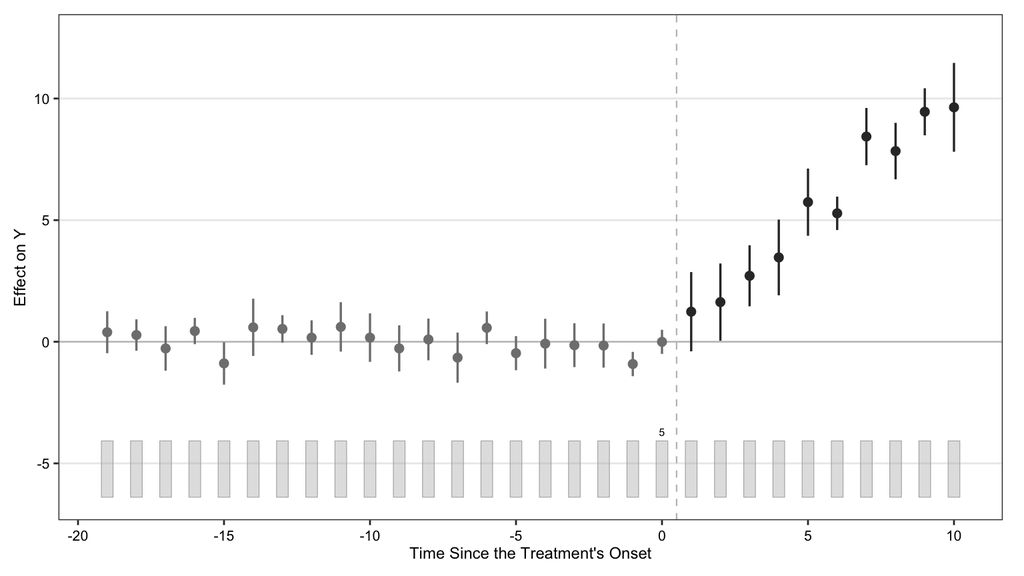

Figure 9: Estimated dynamic treatment effects from the generalized synthetic control fit, with bootstrap confidence intervals.

```r
plot(fit_gs, main = "")
```

**Python**

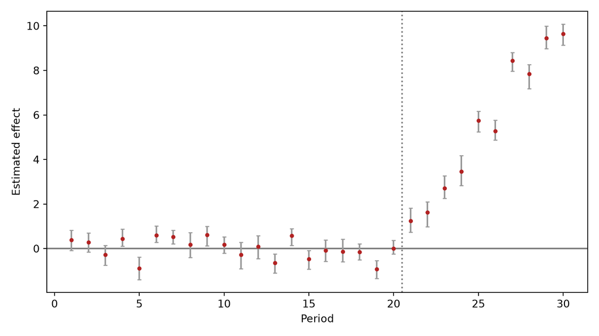

Figure 10: Estimated dynamic treatment effects from the native gsynth fit, with bootstrap 95% intervals.

```python
periods = fit_gs["times"]
eff = fit_gs["eff"]
fig, ax = plt.subplots(figsize=(8, 4.5))
ax.axhline(0, color="grey")
ax.axvline(fit_gs["T0"] + 0.5, color="grey", linestyle=":")
ax.errorbar(periods, eff,
            yerr=[eff - fit_gs["eff_lo"], fit_gs["eff_hi"] - eff],
            fmt="o", color="#B22222", ecolor="0.6", capsize=2, markersize=3)
ax.set_xlabel("Period")
ax.set_ylabel("Estimated effect")
plt.tight_layout()
plt.show()
```

**Stata**

```stata
import delimited "synthetic-control_files/data/simgsynth.csv", clear
quietly fect y, treat(d) unit(id) time(time) cov(x1 x2) method("ife") r(2)
* e(ATTs) holds the event-study: column 1 is event time, column 2 the effect.
matrix E = e(ATTs)
clear
svmat E
twoway line E2 E1, yline(0) xline(0, lpattern(dot)) ///
       xtitle("Periods since treatment") ytitle("Estimated effect")
quietly graph export "sc_figs/fig-gsynth-gap-stata.svg", replace width(1600)
```

```
(encoding automatically selected: ISO-8859-1)
(15 vars, 1,500 obs)




number of observations will be reset to 30
Press any key to continue, or Break to abort
Number of observations (_N) was 0, now 30.
```

[figure not shown]

The estimator also exposes the machinery behind the imputation, which is worth inspecting rather than trusting.

**R**

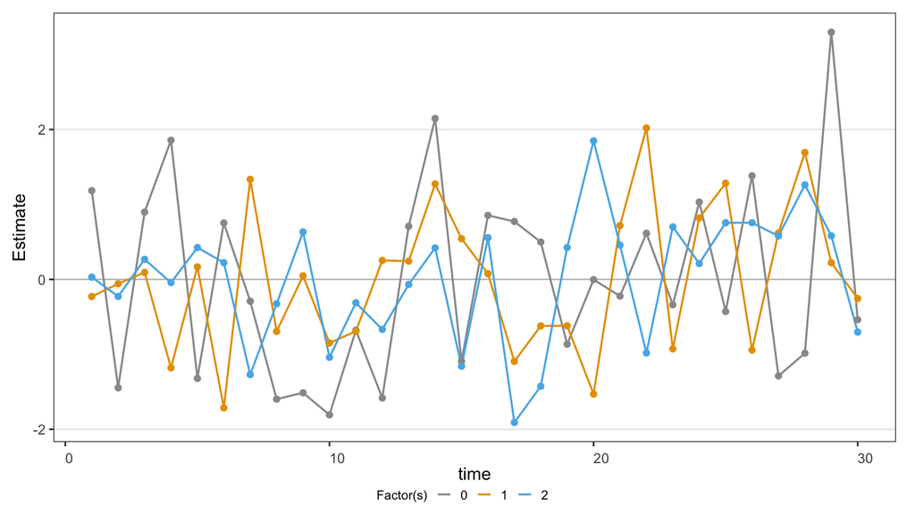

Figure 11: Estimated latent factors driving untreated outcomes.

```r
plot(fit_gs, type = "factors", main = "")
```

**Python**

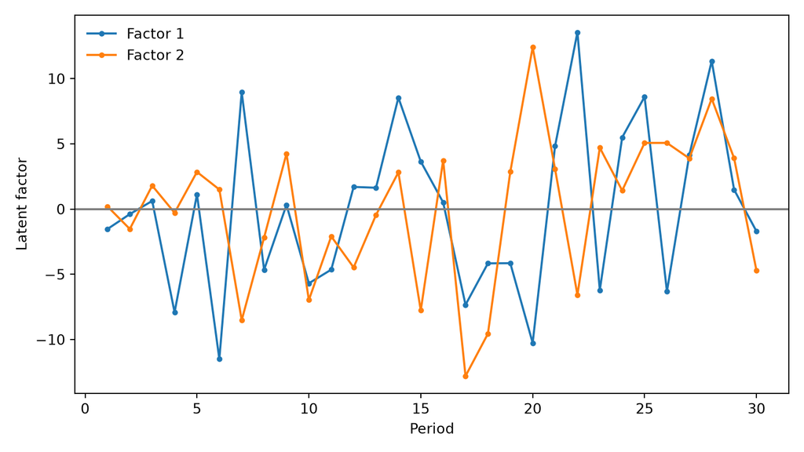

Figure 12: Estimated latent factors driving untreated outcomes.

```python
fig, ax = plt.subplots(figsize=(8, 4.5))
for k in range(fit_gs["F"].shape[1]):
    ax.plot(fit_gs["times"], fit_gs["F"][:, k], marker="o", markersize=3,
            label=f"Factor {k + 1}")
ax.axhline(0, color="grey")
ax.set_xlabel("Period")
ax.set_ylabel("Latent factor")
ax.legend(frameon=False)
plt.tight_layout()
plt.show()
```

**Stata**

```stata
* Stata fect does not expose a built-in latent-factor plot; the factors are an
* internal object. This view is R-specific (gsynth/fect in R).
display "Latent-factor plot is R-specific; see the R tab."
```

```
Latent-factor plot is R-specific; see the R tab.
```

## A Staggered-Adoption Example

`fect` also ships the election-day registration panel used in the original paper: state-level voter turnout, with states adopting reform in different years and never reversing.[^3]

The first step loads the panel and, for every state that ever adopts election day registration, records the first year it did. That gives a quick census of how many states are treated and when the treatment starts spreading.

**R**

```r
# Local cache of fect::turnout (see synthetic-control_files/data/PROVENANCE.md).
turnout <- read.csv("synthetic-control_files/data/turnout.csv")

adopt <- turnout |>
  filter(policy_edr == 1) |>
  group_by(abb) |>
  summarise(first_year = min(year), .groups = "drop") |>
  arrange(first_year)

cat("States:", length(unique(turnout$abb)),
    "| ever treated:", nrow(adopt), "\n")
```

```
States: 47 | ever treated: 9
```

```r
print(as.data.frame(adopt))
```

```
  abb first_year
1  ME       1976
2  MN       1976
3  WI       1976
4  ID       1996
5  NH       1996
6  WY       1996
7  IA       2008
8  MT       2008
9  CT       2012
```

**Python**

```python
turnout = pd.read_csv("synthetic-control_files/data/turnout.csv")

adopt = (turnout[turnout.policy_edr == 1]
         .groupby("abb", as_index=False)["year"].min()
         .rename(columns={"year": "first_year"})
         .sort_values("first_year"))

print("States:", turnout.abb.nunique(), "| ever treated:", len(adopt))
```

```
States: 47 | ever treated: 9
```

```python
print(adopt.to_string(index=False))
```

```
abb  first_year
 ME        1976
 MN        1976
 WI        1976
 ID        1996
 NH        1996
 WY        1996
 IA        2008
 MT        2008
 CT        2012
```

**Stata**

```stata
import delimited "synthetic-control_files/data/turnout.csv", clear
quietly levelsof abb, local(st)
preserve
keep if policy_edr == 1
collapse (min) first_year = year, by(abb)
sort first_year
display "States: " `:word count `st'' " | ever treated: " _N
list abb first_year, noobs
restore
```

```
(encoding automatically selected: ISO-8859-1)
(6 vars, 1,128 obs)



(1,078 observations deleted)



States: 47 | ever treated: 9


  +----------------+
  | abb   first_~r |
  |----------------|
  |  WI       1976 |
  |  ME       1976 |
  |  MN       1976 |
  |  ID       1996 |
  |  WY       1996 |
  |----------------|
  |  NH       1996 |
  |  IA       2008 |
  |  MT       2008 |
  |  CT       2012 |
  +----------------+
```

Nine states adopt across four decades, which is precisely the staggered structure classical SCM cannot handle in one estimand.

The grid below makes the staggering visible. Each cell marks whether a state has election day registration in a given year, and the states are ordered by how long they spend treated, so the block of treated cells grows toward the top.

**R**

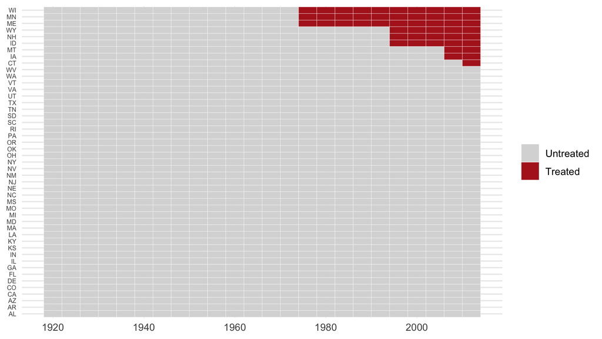

Figure 13: Treatment status by state and year. Staggered adoption means the usable donor pool changes over time.

```r
turnout |>
  mutate(status = factor(policy_edr, levels = c(0, 1),
                         labels = c("Untreated", "Treated"))) |>
  ggplot(aes(year, reorder(abb, policy_edr, sum), fill = status)) +
  geom_tile(colour = "white", linewidth = 0.1) +
  scale_fill_manual(values = c(Untreated = "grey85",
                               Treated = PAL[["treated"]])) +
  labs(x = NULL, y = NULL, fill = NULL) +
  theme(axis.text.y = element_text(size = 6))
```

**Python**

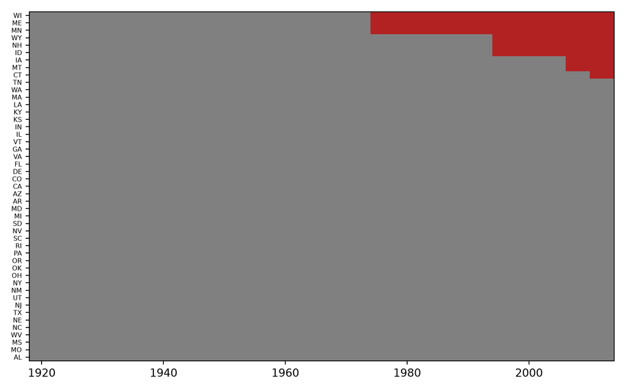

Figure 14

```python
grid = turnout.pivot(index="abb", columns="year", values="policy_edr")
grid = grid.loc[grid.sum(axis=1).sort_values().index]   # order by exposure

fig, ax = plt.subplots(figsize=(8, 5))
ax.pcolormesh(grid.columns, range(len(grid.index)), grid.values,
              cmap=plt.cm.colors.ListedColormap(["grey", "#B22222"]))
ax.set_yticks(range(len(grid.index)))
ax.set_yticklabels(grid.index, fontsize=6)
ax.set_xlabel("")
plt.tight_layout()
plt.show()
```

**Stata**

```stata
import delimited "synthetic-control_files/data/turnout.csv", clear
encode abb, gen(state)
* first-draft heatmap via scatter of treated cells (a heatplot package gives a
* cleaner grid: ssc install heatplot).
twoway (scatter state year if policy_edr == 0, msymbol(square) mcolor(gs13) msize(small)) ///
       (scatter state year if policy_edr == 1, msymbol(square) mcolor("178 34 34") msize(small)), ///
       legend(order(1 "Untreated" 2 "Treated")) ytitle("") xtitle("") ylabel(none)
quietly graph export "sc_figs/fig-turnout-status-stata.svg", replace width(1600)
```

```
(encoding automatically selected: ISO-8859-1)
(6 vars, 1,128 obs)
```

[figure not shown]

**R**

```r
fit_turnout <- fect(
  turnout ~ policy_edr,
  data = turnout,
  index = c("abb", "year"),
  method = "gsynth",
  force = "two-way",
  CV = TRUE,
  r = c(0, 5),
  se = TRUE,
  nboots = 200,
  parallel = FALSE
)
```

**Python**

```python
# Same native estimator, now with staggered adoption and no covariates.
turnout = pd.read_csv("synthetic-control_files/data/turnout.csv")
fit_turnout = gsynth_fit(turnout, y="turnout", d="policy_edr",
                         unit="abb", time="year", x=(), r=2, nboot=200)
```

**Stata**

```stata
import delimited "synthetic-control_files/data/turnout.csv", clear
encode abb, gen(state)
* R's method="gsynth" is interactive fixed effects; in Stata fect that is "ife".
* Stata fect takes a single integer r(); r=2 is the count CV selects here.
fect turnout, treat(policy_edr) unit(state) time(year) method("ife") r(2)
```

```
(encoding automatically selected: ISO-8859-1)
(6 vars, 1,128 obs)


Balanced Panel Data
```

The fit reports a single average effect across all treated state years, together with the number of latent factors the procedure kept. Because each Stata block runs in its own session, the Stata tab refits the model before reading the result.

**R**

```r
cat("Factors selected:", fit_turnout$r.cv, "\n")
```

```
Factors selected: 2
```

```r
cat("Estimated ATT:", round(fit_turnout$est.avg[1], 3),
    " SE:", round(fit_turnout$est.avg[2], 3), "\n")
```

```
Estimated ATT: 5.13  SE: 1.856
```

**Python**

```python
print("Factors used:", fit_turnout["r"])
```

```
Factors used: 2
```

```python
print("Estimated ATT:", round(fit_turnout["att"], 3))
```

```
Estimated ATT: 5.13
```

**Stata**

```stata
import delimited "synthetic-control_files/data/turnout.csv", clear
encode abb, gen(state)
quietly fect turnout, treat(policy_edr) unit(state) time(year) method("ife") r(2)
matrix A = e(ATT)          // columns: ATT, N (treated observations)
display "Estimated ATT: " %6.3f A[1,1]
```

```
(encoding automatically selected: ISO-8859-1)
(6 vars, 1,128 obs)




Estimated ATT:  5.203
```

Averages hide timing. Aligning every state to its own adoption year and plotting the effect period by period shows whether turnout responds at once or gradually, and, just as important, whether anything is already moving before the reform. Flat pre-adoption estimates are the staggered analogue of a clean pre-treatment fit.

**R**

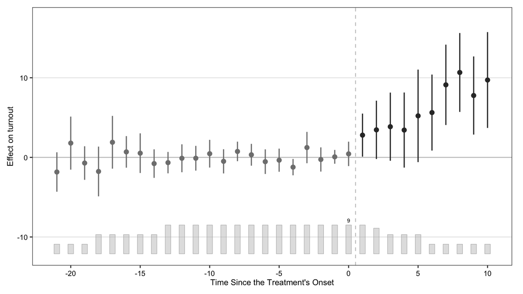

Figure 15: Dynamic effects of election-day registration on turnout, aligned to each state’s own adoption year.

```r
plot(fit_turnout, main = "")
```

**Python**

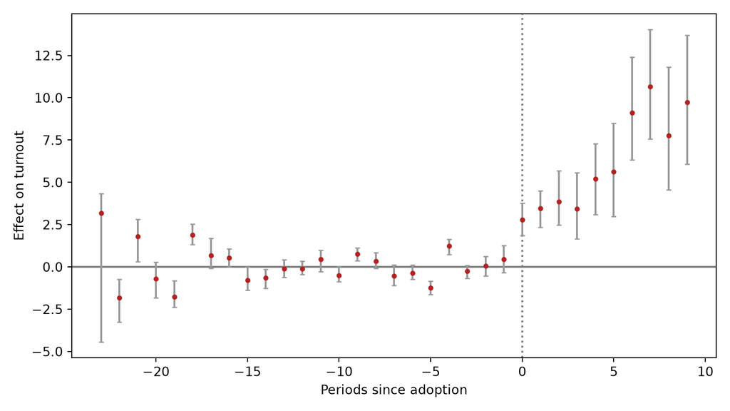

Figure 16: Dynamic effects of election-day registration on turnout, aligned to each state’s adoption year, with bootstrap 95% intervals.

```python
k, m = fit_turnout["evt_k"], fit_turnout["evt_m"]
fig, ax = plt.subplots(figsize=(8, 4.5))
ax.axhline(0, color="grey")
ax.axvline(0, color="grey", linestyle=":")
ax.errorbar(k, m, yerr=[m - fit_turnout["evt_lo"], fit_turnout["evt_hi"] - m],
            fmt="o", color="#B22222", ecolor="0.6", capsize=2, markersize=3)
ax.set_xlabel("Periods since adoption")
ax.set_ylabel("Effect on turnout")
plt.tight_layout()
plt.show()
```

**Stata**

```stata
import delimited "synthetic-control_files/data/turnout.csv", clear
encode abb, gen(state)
quietly fect turnout, treat(policy_edr) unit(state) time(year) method("ife") r(2)
* e(ATTs) holds the event-study: column 1 is event time, column 2 the effect.
matrix E = e(ATTs)
clear
svmat E
twoway line E2 E1, yline(0) xline(0, lpattern(dot)) ///
       xtitle("Periods since adoption") ytitle("Effect on turnout")
quietly graph export "sc_figs/fig-turnout-gap-stata.svg", replace width(1600)
```

```
(encoding automatically selected: ISO-8859-1)
(6 vars, 1,128 obs)





number of observations will be reset to 33
Press any key to continue, or Break to abort
Number of observations (_N) was 0, now 33.
```

[figure not shown]

Because effects are aligned to each state’s own adoption year, period zero means something different in calendar time for each unit. The pre-treatment periods now serve the role the pre-treatment path served in classical SCM: if estimated effects are already nonzero before adoption, the imputation model is not capturing the untreated trajectory.

## Does the General Tool Replace the Specific One?

Gsynth handles everything classical SCM handles, plus cases classical SCM cannot express. A natural conclusion is that you should simply always use it. That conclusion is wrong, and Proposition 99 shows why.

The two are not the same estimator. Classical SCM puts convex weights on donor *units*, so the counterfactual is a blend of real states and cannot leave their range. Gsynth fits a factor model to the untreated observations, estimates California’s loadings from its pre-period, and *imputes* the counterfactual. Nothing constrains that imputation to resemble any real state. Run both on the same data and they disagree.

The disagreement is not a small numerical wobble. It depends almost entirely on one tuning choice: how many latent factors the model is allowed.

**R**

```r
smoking_fect <- smoking_df |>
  mutate(treat = as.integer(state == "California" & year >= 1989))

r_sweep <- lapply(0:5, function(rr) {
  set.seed(20260720)
  invisible(capture.output(
    f <- fect(cigsale ~ treat, data = smoking_fect,
              index = c("state_id", "year"), method = "gsynth",
              force = "two-way", CV = FALSE, r = rr,
              se = TRUE, nboots = 200, parallel = FALSE)
  ))
  pos <- which(f$id == ca_id)
  g <- f$Y.dat[, pos] - f$Y.ct[, pos]
  data.frame(Factors = rr,
             ATT = round(f$est.avg[1], 2),
             SE = round(f$est.avg[2], 2),
             `Pre-RMSE` = round(sqrt(mean(g[f$rawtime <= 1988]^2)), 2),
             check.names = FALSE)
}) |> bind_rows()

r_sweep$`Classical SCM ATT` <- round(mean(gap_ca[!pre_ca]), 2)
r_sweep
```

```
  Factors    ATT   SE Pre-RMSE Classical SCM ATT
1       0 -27.35 2.66     7.16            -18.72
2       1 -13.89 3.39     4.06            -18.72
3       2  -0.40 9.94     1.36            -18.72
4       3  -1.87 8.22     1.35            -18.72
5       4  -1.90 8.13     1.35            -18.72
6       5  -0.45 8.03     1.35            -18.72
```

**Python**

```python
smoking_fect = smoking.assign(
    treat=((smoking.state == "California") & (smoking.year >= 1989)).astype(int)
)
rows = []
for rr in range(0, 6):
    f = Fect(data=smoking_fect, Y="cigsale", D="treat",
             index=["state_id", "year"], method="gsynth", force="two-way",
             CV=False, r=(rr, rr), se=True, nboots=200, parallel=False)
    rows.append({"Factors": rr, "ATT": round(f.est_avg[0], 2),
                 "SE": round(f.est_avg[1], 2)})
print(pd.DataFrame(rows).to_string(index=False))
```

[output not shown]

**Stata**

```stata
import delimited "synthetic-control_files/data/smoking.csv", clear
destring lnincome beer age15to24, replace force
encode state, gen(state_id)
gen treat = (state == "California" & year >= 1989)
tempname R
postfile `R' int factors double att using "synthetic-control_files/stata/_rsweep", replace
forvalues rr = 0/5 {
    if `rr' == 0 {
        quietly fect cigsale, treat(treat) unit(state_id) time(year) method("fe")
    }
    else {
        quietly fect cigsale, treat(treat) unit(state_id) time(year) method("ife") r(`rr')
    }
    matrix A = e(ATT)
    post `R' (`rr') (A[1,1])
}
postclose `R'
use "synthetic-control_files/stata/_rsweep", clear
list, noobs
```

```
(encoding automatically selected: ISO-8859-2)
(7 vars, 1,209 obs)

lnincome: contains nonnumeric characters; replaced as double
(195 missing values generated)
beer: contains nonnumeric characters; replaced as double
(663 missing values generated)
age15to24: contains nonnumeric characters; replaced as double
(390 missing values generated)









  +----------------------+
  | factors          att |
  |----------------------|
  |       0   -27.349111 |
  |       1   -13.870756 |
  |       2   -.72578989 |
  |       3   -23.052441 |
  |       4   -22.224885 |
  |----------------------|
  |       5   -25.717255 |
  +----------------------+
```

Read the first two columns together. As the model is given more factors, its pre-treatment fit improves steadily, from an RMSE above 7 down to about 1.35, which is *better* than classical SCM manages. And as the fit improves, the estimated effect collapses from $-27$ toward zero, with standard errors wide enough to cover almost anything.

That is overfitting, and it is worth being precise about the mechanism. California is one unit with nineteen pre-treatment periods. Four latent factors give the model enough freedom to reproduce almost any pre-1988 path, and that same freedom carries into the post-1988 period, where it absorbs the treatment effect instead of revealing it. Cross-validation does not save you here: before we fixed a seed, repeated runs of the same specification selected different factor counts and returned estimates ranging from $-1.9$ to $-13.9$. Constraining the loadings with `loading.bound = "simplex"` changes the answer again rather than settling it.

**R**

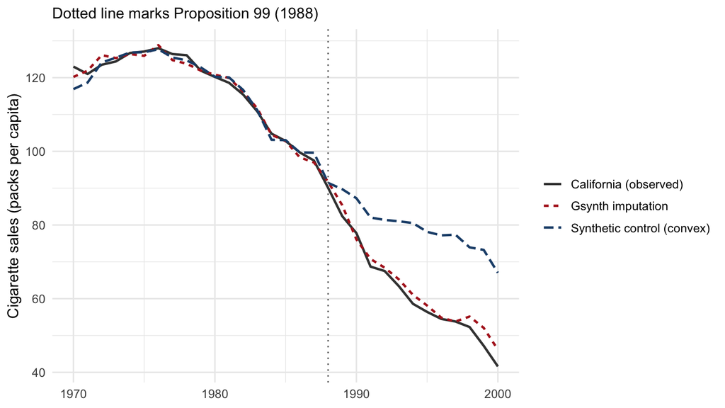

Figure 17: Two counterfactuals for California from the same data. The convex synthetic control stays near the observed pre-1988 path without reproducing it exactly; the four-factor imputation tracks it almost perfectly and then follows California downward, leaving little gap to attribute to the policy.

```r
set.seed(20260720)
invisible(capture.output(
  fit_gs_ca <- fect(cigsale ~ treat, data = smoking_fect,
                    index = c("state_id", "year"), method = "gsynth",
                    force = "two-way", CV = TRUE, r = c(0, 5),
                    se = TRUE, nboots = 200, parallel = FALSE)
))
pos_ca <- which(fit_gs_ca$id == ca_id)

data.frame(
  year = years_ca,
  `California (observed)` = obs_ca,
  `Synthetic control (convex)` = synth_ca,
  `Gsynth imputation` = fit_gs_ca$Y.ct[, pos_ca],
  check.names = FALSE
) |>
  pivot_longer(-year, names_to = "series", values_to = "cigsale") |>
  ggplot(aes(year, cigsale, colour = series, linetype = series)) +
  geom_vline(xintercept = 1988, linetype = "dotted", colour = "grey40") +
  geom_line(linewidth = 0.9) +
  scale_colour_manual(values = c(`California (observed)` = "grey25",
                                 `Synthetic control (convex)` = PAL[["synth"]],
                                 `Gsynth imputation` = PAL[["treated"]])) +
  labs(x = NULL, y = "Cigarette sales (packs per capita)",
       colour = NULL, linetype = NULL,
       subtitle = "Dotted line marks Proposition 99 (1988)")
```

**Python**

```python
# convex synthetic path (from pysyncon, above) vs the gsynth imputation
fit_gs_ca = Fect(data=smoking_fect, Y="cigsale", D="treat",
                 index=["state_id", "year"], method="gsynth", force="two-way",
                 CV=True, r=(0, 5), se=True, nboots=200, parallel=False)
gsynth_ct = fit_gs_ca.Y_ct_for("California")   # imputed counterfactual

fig, ax = plt.subplots(figsize=(8, 4.5))
ax.plot(years, obs_path, color="0.25", label="California (observed)")
ax.plot(years, synth_path, color="#1F4E79", label="Synthetic control (convex)")
ax.plot(years, gsynth_ct, color="#B22222", label="Gsynth imputation")
ax.axvline(1988, color="grey", linestyle=":")
ax.legend(frameon=False)
plt.show()
```

[output not shown]

**Stata**

```stata
* Overlaying the convex synth path (from the Prop 99 fit, _ca_out.dta) and the
* gsynth imputation requires exporting both counterfactuals; this comparison is
* cleanest in R. First-draft placeholder.
display "See the R tab: overlay of convex SCM vs gsynth imputation for California."
```

```
See the R tab: overlay of convex SCM vs gsynth imputation for California.
```

The lesson generalizes beyond this dataset, and it qualifies advice given earlier in this guide. **Pre-treatment fit is necessary but not sufficient.** An estimator flexible enough to fit any pre-treatment path tells you nothing by fitting yours. What made the pre-treatment fit meaningful in the classical case was that convexity made a good fit *hard to achieve*: only a genuinely similar blend of real states could produce one. Remove the constraint and a good fit stops being evidence. The proportion-outcome simulation made the same point from a different direction, where the unconstrained estimator also fit better and also produced counterfactuals that could not be true.

So the choice is not “general tool versus specific tool.” It is a question about your design:

| Your design | Use |
| --- | --- |
| One treated unit, clean treatment date, adequate pre-period | Classical SCM. Convexity is doing real work, and the weights are reportable. |
| Multiple treated units, staggered adoption, reversal, or missing data | Gsynth or another `fect` estimator. Classical SCM cannot express the design at all. |
| One treated unit, but poor donor support | Augmented SCM, with the extrapolation stated openly. |

The turnout example earlier is where gsynth earns its keep: nine states adopting across four decades is a design classical SCM cannot represent in a single estimand. Proposition 99 is the opposite case, and there the extra flexibility is a liability rather than an upgrade.

## Choices You Must Report

Report the treatment coding, treatment timing, panel indices, method, fixed effects, candidate factor range, cross-validation settings, inference procedure, bootstrap count, missing-data handling, and package versions. Also state whether treatment can switch on and off.

Two `fect` specifics are easy to get wrong. `loading.bound = "simplex"`, which keeps treated-unit loadings inside the donor support and is closest to the classical SCM intuition, and `vartype = "parametric"` both require `time.component.from = "nevertreated"`; without it the call errors or silently falls back. And `fect` objects have no `summary()` method, so use `print()`.

# Augmented Synthetic Controls

Classical SCM works best when a convex combination of donors reproduces the treated unit. When the treated unit sits outside the donor convex hull, as in the poor-support scenario above, no set of nonnegative weights summing to one can close the gap.

Augmented SCM adds an outcome-model correction to the classical estimate (Ben-Michael, Feller, and Rothstein 2021):

$$\widehat{Y}_{1t}^{AugSCM}(0) =
\widehat{Y}_{1t}^{SCM}(0) + \widehat{\text{bias correction}},$$

where the correction, commonly from a ridge regression, estimates the remaining pre-treatment imbalance and adjusts for it. The logic is bias-corrected matching: build the most transparent synthetic control available, measure what it still gets wrong before treatment, and correct by that amount.

| What augmentation buys | What it costs |
| --- | --- |
| Better fit when exact classical fit is infeasible | More model dependence |
| Explicit bias correction | Possible negative donor weights |
| A controlled form of extrapolation | Weaker “weighted average of real donors” intuition |

## How Much Does It Help?

We can measure this directly. Using the same factor-model simulation, we vary how far outside the donor hull the treated unit sits and compare classical SCM against ridge-augmented SCM, with the true effect known.

**Simulation design (click to expand)**

```r
# One donor pool, treated loadings 1.1 / 1.5 / 2.6 (just outside to far outside
# the hull). Written to disk so all three languages read identical panels.
build_panel <- function(lam_val, seed = 20260720) {
  set.seed(seed)
  lam <- cbind(runif(J, 0, 1), runif(J, 0, 1))
  alpha <- rnorm(J, 0, 3)
  Y <- matrix(NA_real_, nrow = J + 1, ncol = TT)
  for (i in 1:J) {
    Y[i + 1, ] <- 120 + alpha[i] +
      8 * lam[i, 1] * f1 + 8 * lam[i, 2] * f2 + rnorm(TT, 0, 1)
  }
  Y[1, ] <- 120 + 8 * lam_val * f1 + 8 * lam_val * f2 + rnorm(TT, 0, 1) + tau
  data.frame(id = rep(1:(J + 1), each = TT),
             time = rep(1:TT, times = J + 1),
             Y = as.vector(t(Y))) |>
    mutate(trt = as.integer(id == 1 & time > T0))
}
for (v in c(1.1, 1.5, 2.6)) {
  tag <- sub("[.]", "p", sprintf("%.1f", v))
  write.csv(build_panel(v),
            file.path(dir_sim, paste0("sim_aug_", tag, ".csv")), row.names = FALSE)
}
```

**R**

```r
post_att <- function(a) {
  s <- summary(a)$att
  mean(s$Estimate[s$Time > T0], na.rm = TRUE)
}

sweep_res <- lapply(c(1.1, 1.5, 2.6), function(v) {
  tag <- sub("[.]", "p", sprintf("%.1f", v))
  pan <- read.csv(paste0("synthetic-control_files/data/sim_aug_", tag, ".csv"))
  a_scm   <- augsynth::augsynth(Y ~ trt, unit = id, time = time, data = pan,
                      progfunc = "none",  scm = TRUE)
  a_ridge <- augsynth::augsynth(Y ~ trt, unit = id, time = time, data = pan,
                      progfunc = "ridge", scm = TRUE)
  data.frame(
    `Treated loading` = v,
    `SCM ATT`         = round(post_att(a_scm), 2),
    `SCM imbalance`   = round(a_scm$l2_imbalance, 2),
    `Augmented ATT`   = round(post_att(a_ridge), 2),
    `Aug. imbalance`  = round(a_ridge$l2_imbalance, 2),
    `Min weight`      = round(min(a_ridge$weights), 3),
    check.names = FALSE
  )
}) |> bind_rows()

sweep_res$`True ATT` <- round(mean(tau[(T0 + 1):TT]), 2)
sweep_res
```

```
  Treated loading SCM ATT SCM imbalance Augmented ATT Aug. imbalance Min weight
1             1.1   -9.24          8.20         -9.92           3.03     -0.196
2             1.5   -7.30         17.98         -9.27           6.56     -0.251
3             2.6   -1.48         49.06         -9.03           8.80     -0.700
  True ATT
1     -9.6
2     -9.6
3     -9.6
```

**Python**

```python
from pysyncon import AugSynth

rows = []
for v in [1.1, 1.5, 2.6]:
    tag = f"{v:.1f}".replace(".", "p")
    pan = pd.read_csv(f"synthetic-control_files/data/sim_aug_{tag}.csv")
    donors = [i for i in pan.id.unique() if i != 1]
    dp = Dataprep(
        foo=pan, dependent="Y", unit_variable="id", time_variable="time",
        treatment_identifier=1, controls_identifier=donors,
        predictors=[], predictors_op="mean",
        special_predictors=[("Y", [t], "mean") for t in range(1, T0 + 1)],
        time_predictors_prior=range(1, T0 + 1), time_optimize_ssr=range(1, T0 + 1),
    )
    aug = AugSynth()
    aug.fit(dp)
    rows.append({"Treated loading": v, "Augmented ATT": round(aug.att(range(T0 + 1, TT + 1))["att"], 2)})
print(pd.DataFrame(rows).to_string(index=False))
```

```
 Treated loading  Augmented ATT
             1.1          -9.79
             1.5          -9.64
             2.6          -9.63
```

**Stata**

```stata
* Stata augmented SCM via allsynth (Wiltshire; needs distinct, elasticregress).
* allsynth's kept file has `gap` (classical) and `gap_bc` (ridge-augmented).
tempname A
postfile `A' double loading double scm_att double aug_att using "synthetic-control_files/stata/_augsweep", replace
foreach lv in 1.1 1.5 2.6 {
    local tag = subinstr("`lv'", ".", "p", .)
    import delimited "synthetic-control_files/data/sim_aug_`tag'.csv", clear
    tsset id time
    local pre ""
    forvalues t = 1/20 {
        local pre "`pre' y(`t')"
    }
    quietly allsynth y `pre', trunit(1) trperiod(21) mspeperiod(1(1)20) ///
        bcorrect(merge ridge) keep("synthetic-control_files/stata/_a", replace)
    preserve
    use "synthetic-control_files/stata/_a", clear
    quietly summarize gap if _time > 20
    scalar sa = r(mean)
    quietly summarize gap_bc if _time > 20
    scalar aa = r(mean)
    restore
    post `A' (`lv') (sa) (aa)
}
postclose `A'
use "synthetic-control_files/stata/_augsweep", clear
format scm_att aug_att %6.2f
list, noobs
```

```
 10.     preserve
 11.     use "synthetic-control_files/stata/_a", clear
 12.     quietly summarize gap if _time > 20
 13.     scalar sa = r(mean)
 14.     quietly summarize gap_bc if _time > 20
 15.     scalar aa = r(mean)
 16.     restore
 17.     post `A' (`lv') (sa) (aa)
 18. }
(encoding automatically selected: ISO-8859-1)
(4 vars, 910 obs)

Panel variable: id (strongly balanced)
 Time variable: time, 1 to 35
         Delta: 1 unit
(encoding automatically selected: ISO-8859-1)
(4 vars, 910 obs)

Panel variable: id (strongly balanced)
 Time variable: time, 1 to 35
         Delta: 1 unit
(encoding automatically selected: ISO-8859-1)
(4 vars, 910 obs)

Panel variable: id (strongly balanced)
 Time variable: time, 1 to 35
         Delta: 1 unit





  +-----------------------------+
  | loading   scm_att   aug_att |
  |-----------------------------|
  |     1.1     -9.24     -9.29 |
  |     1.5     -7.30     -7.75 |
  |     2.6     -1.48     -3.55 |
  +-----------------------------+

```

[output cut: 34 more lines]

[output not shown]

Donor loadings run from 0 to 1, so a treated loading of 1.1 is just outside the hull and 2.6 is far outside. Three things are visible.

One caveat about reading this table too optimistically. These data were generated from a factor model, and a ridge correction on pre-treatment outcomes is well suited to exactly that structure, so this is close to a best case for augmentation. It demonstrates that the bias correction does what it claims when the outcome model is roughly right. It is not a promise that augmentation recovers the truth when the model is wrong, and it is not a licence to treat a badly chosen donor pool as fixable.

**R**

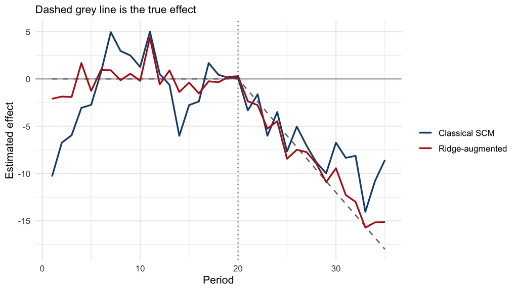

Figure 18: Classical and ridge-augmented estimates against the true effect, for a treated unit moderately outside the donor hull.

```r
pan_mid <- read.csv("synthetic-control_files/data/sim_aug_1p5.csv")
a_scm   <- augsynth::augsynth(Y ~ trt, unit = id, time = time, data = pan_mid,
                    progfunc = "none",  scm = TRUE)
a_ridge <- augsynth::augsynth(Y ~ trt, unit = id, time = time, data = pan_mid,
                    progfunc = "ridge", scm = TRUE)

bind_rows(
  summary(a_scm)$att   |> mutate(Method = "Classical SCM"),
  summary(a_ridge)$att |> mutate(Method = "Ridge-augmented")
) |>
  filter(!is.na(Estimate)) |>
  ggplot(aes(Time, Estimate, colour = Method)) +
  geom_hline(yintercept = 0, colour = "grey60") +
  geom_vline(xintercept = T0, linetype = "dotted", colour = "grey40") +
  geom_line(data = data.frame(Time = 1:TT, Estimate = tau),
            aes(Time, Estimate), colour = "grey45",
            linetype = "dashed", linewidth = 0.7, inherit.aes = FALSE) +
  geom_line(linewidth = 0.9) +
  scale_colour_manual(values = c("Classical SCM" = PAL[["synth"]],
                                 "Ridge-augmented" = PAL[["treated"]])) +
  labs(x = "Period", y = "Estimated effect", colour = NULL,
       subtitle = "Dashed grey line is the true effect")
```

**Python**

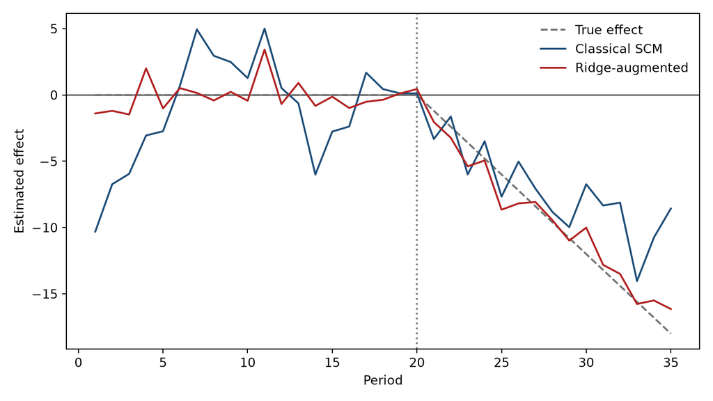

Figure 19

```python
pan = pd.read_csv("synthetic-control_files/data/sim_aug_1p5.csv")
donors = [i for i in pan.id.unique() if i != 1]
dp = Dataprep(
    foo=pan, dependent="Y", unit_variable="id", time_variable="time",
    treatment_identifier=1, controls_identifier=donors,
    predictors=[], predictors_op="mean",
    special_predictors=[("Y", [t], "mean") for t in range(1, T0 + 1)],
    time_predictors_prior=range(1, T0 + 1), time_optimize_ssr=range(1, T0 + 1),
)
scm = Synth();     scm.fit(dp)
aug = AugSynth();  aug.fit(dp)

periods = list(range(1, TT + 1))
eff_scm = [scm.att(time_period=[t])["att"] for t in periods]
eff_aug = [aug.att(time_period=[t])["att"] for t in periods]
tau_vec = [(-1.2 * (t - T0) if t > T0 else 0) for t in periods]

fig, ax = plt.subplots(figsize=(8, 4.5))
ax.axhline(0, color="grey")
ax.axvline(T0, color="grey", linestyle=":")
ax.plot(periods, tau_vec, color="0.45", linestyle="--", label="True effect")
ax.plot(periods, eff_scm, color="#1F4E79", label="Classical SCM")
ax.plot(periods, eff_aug, color="#B22222", label="Ridge-augmented")
ax.set_xlabel("Period")
ax.set_ylabel("Estimated effect")
ax.legend(frameon=False)
plt.tight_layout()
plt.show()
```

**Stata**

```stata
import delimited "synthetic-control_files/data/sim_aug_1p5.csv", clear
tsset id time
local pre ""
forvalues t = 1/20 {
    local pre "`pre' y(`t')"
}
quietly allsynth y `pre', trunit(1) trperiod(21) mspeperiod(1(1)20) ///
    bcorrect(merge ridge) keep("synthetic-control_files/stata/_aug15", replace)
use "synthetic-control_files/stata/_aug15", clear
gen tau = cond(_time > 20, -1.2 * (_time - 20), 0)   // deterministic truth
twoway (line tau _time, lcolor(gs8) lpattern(dash)) ///
       (line gap _time, lcolor("31 78 121")) ///
       (line gap_bc _time, lcolor("178 34 34")), ///
       yline(0) xline(20, lpattern(dot)) ///
       legend(order(1 "True effect" 2 "Classical SCM" 3 "Ridge-augmented")) ///
       xtitle("Period") ytitle("Estimated effect")
quietly graph export "sc_figs/fig-augsynth-stata.svg", replace width(1600)
```

[output not shown]

[figure not shown]

Report the unaugmented fit, the augmented fit, the regularization choice, whether weights become negative, and whether conclusions change across plausible tuning choices.

# Synthetic Control for Proportion Outcomes

“Proportion synthetic control” is not an estimator name. It is a warning that your outcome is bounded: turnout, vaccination coverage, graduation rates, compliance, or the share of forest area deforested all live in $[0, 1]$.

## Why Convexity Matters Here

Recall the constraints $w_j \geq 0$ and $\sum_j w_j = 1$. Because the synthetic outcome is a convex combination of donor values, it can never fall outside the range of the donors themselves. If every donor’s deforestation share lies in $[0, 1]$, so does the synthetic counterfactual, automatically.

Estimators that relax convexity lose this guarantee. Augmented SCM permits negative weights; unconstrained regression, matrix completion, and factor models extrapolate freely. That flexibility buys better pre-treatment fit and can produce a counterfactual that is arithmetically impossible.

This is measurable rather than hypothetical. We simulate bounded panels where donors fit the treated unit’s pre-period well, then compare a convex synthetic control against an unconstrained least-squares fit on the same data.

**Simulation design (click to expand)**

```r
set.seed(31415)
Jp <- 10; T0p <- 18; TTp <- 30
pre_p <- 1:T0p

draw_bounded_panel <- function() {
  wave <- sin(seq(0, 2 * pi, length.out = TTp))
  common <- 0.9 * wave
  div <- c(rep(0, T0p), seq(0, 1, length.out = TTp - T0p))   # diverge after pre-period
  P <- matrix(NA_real_, nrow = Jp + 1, ncol = TTp)
  for (i in 1:Jp) {
    s <- runif(1, -1, 1) * 2.5
    eta <- qlogis(runif(1, 0.15, 0.35)) + common +
      0.05 * rnorm(1) * wave + s * div + rnorm(TTp, 0, 0.01)
    P[i + 1, ] <- plogis(eta)
  }
  P[1, ] <- plogis(qlogis(runif(1, 0.14, 0.30)) + common + rnorm(TTp, 0, 0.01))
  P
}
# 200 draws, stacked long, written to disk for the other languages.
draws <- do.call(rbind, lapply(1:200, function(r) {
  P <- draw_bounded_panel()
  data.frame(rep = r, unit = rep(1:(Jp + 1), each = TTp),
             time = rep(1:TTp, times = Jp + 1), share = as.vector(t(P)))
}))
write.csv(draws, file.path(dir_sim, "sim_prop_draws.csv"), row.names = FALSE)
```

**R**

```r
Jp <- 10; T0p <- 18; TTp <- 30; pre_p <- 1:T0p

# Convex SCM weights: gradient steps, clip negatives to zero, renormalize to sum to one.
scm_weights <- function(D, y, pre, iter = 30000, lr = 5e-3) {
  Jn <- ncol(D); w <- rep(1 / Jn, Jn)
  Dp <- D[pre, , drop = FALSE]; yp <- y[pre]
  for (k in 1:iter) {
    w <- w - lr * as.vector(t(Dp) %*% (Dp %*% w - yp))
    w[w < 0] <- 0
    s <- sum(w); if (s > 0) w <- w / s
  }
  w
}

draws <- read.csv("synthetic-control_files/data/sim_prop_draws.csv")
reps <- t(sapply(1:200, function(r) {
  sub <- draws[draws$rep == r, ]
  P <- matrix(sub$share, nrow = Jp + 1, byrow = TRUE)
  D <- t(P[-1, ]); y <- P[1, ]
  uc <- lm(y[pre_p] ~ D[pre_p, ])
  cf_uc <- as.vector(cbind(1, D) %*% ifelse(is.na(coef(uc)), 0, coef(uc)))
  cf_scm <- as.vector(D %*% scm_weights(D, y, pre_p))
  c(min_uc = min(cf_uc), max_uc = max(cf_uc),
    min_scm = min(cf_scm), max_scm = max(cf_scm),
    rmse_uc = sqrt(mean((cf_uc[pre_p] - y[pre_p])^2)),
    rmse_scm = sqrt(mean((cf_scm[pre_p] - y[pre_p])^2)))
}))

data.frame(
  Estimator = c("Convex SCM", "Unconstrained"),
  `Median pre-period RMSE` = round(c(median(reps[, "rmse_scm"]),
                                     median(reps[, "rmse_uc"])), 5),
  `% draws with counterfactual < 0` = round(c(mean(reps[, "min_scm"] < 0),
                                              mean(reps[, "min_uc"] < 0)) * 100, 1),
  `% draws with counterfactual > 1` = round(c(mean(reps[, "max_scm"] > 1),
                                              mean(reps[, "max_uc"] > 1)) * 100, 1),
  `Worst value` = round(c(min(reps[, "min_scm"]), min(reps[, "min_uc"])), 3),
  check.names = FALSE
)
```

```
      Estimator Median pre-period RMSE % draws with counterfactual < 0
1    Convex SCM                0.00353                             0.0
2 Unconstrained                0.00126                            21.5
  % draws with counterfactual > 1 Worst value
1                             0.0       0.016
2                             2.5      -0.576
```

**Python**

```python
Jp, T0p, TTp = 10, 18, 30
pre = np.arange(T0p)

def scm_weights(D, y, iters=30000, lr=5e-3):
    w = np.full(D.shape[1], 1 / D.shape[1])
    Dp, yp = D[:T0p], y[:T0p]
    for _ in range(iters):
        w = w - lr * (Dp.T @ (Dp @ w - yp))
        w[w < 0] = 0
        s = w.sum()
        if s > 0:
            w /= s
    return w

draws = pd.read_csv("synthetic-control_files/data/sim_prop_draws.csv")
rec = []
for r in range(1, 201):
    P = (draws[draws.rep == r]
         .pivot(index="unit", columns="time", values="share").values)  # (Jp+1, TTp)
    D, y = P[1:].T, P[0]
    X = np.column_stack([np.ones(T0p), D[:T0p]])
    beta, *_ = np.linalg.lstsq(X, y[:T0p], rcond=None)
    cf_uc = np.column_stack([np.ones(TTp), D]) @ beta
    cf_scm = D @ scm_weights(D, y)
    rec.append((cf_uc.min(), cf_uc.max(), cf_scm.min(), cf_scm.max(),
                np.sqrt(((cf_uc[:T0p] - y[:T0p]) ** 2).mean()),
                np.sqrt(((cf_scm[:T0p] - y[:T0p]) ** 2).mean())))
reps = np.array(rec)

print(pd.DataFrame({
    "Estimator": ["Convex SCM", "Unconstrained"],
    "Median pre-period RMSE": [round(np.median(reps[:, 5]), 5), round(np.median(reps[:, 4]), 5)],
    "% cf < 0": [round((reps[:, 2] < 0).mean() * 100, 1), round((reps[:, 0] < 0).mean() * 100, 1)],
    "% cf > 1": [round((reps[:, 3] > 1).mean() * 100, 1), round((reps[:, 1] > 1).mean() * 100, 1)],
    "Worst": [round(reps[:, 2].min(), 3), round(reps[:, 0].min(), 3)],
}).to_string(index=False))
```

```
    Estimator  Median pre-period RMSE  % cf < 0  % cf > 1  Worst
   Convex SCM                 0.00353       0.0       0.0  0.016
Unconstrained                 0.00126      21.5       2.5 -0.576
```

**Stata**

```stata
import delimited "synthetic-control_files/data/sim_prop_draws.csv", clear
mata:
// convex SCM weights: gradient step, clip negatives, renormalize (simplex heuristic)
real colvector scm_w(real matrix Dm, real colvector y, real scalar T0,
                     real scalar iters, real scalar lr) {
    real scalar J, k, s
    real colvector w
    real matrix Dp
    Dp = Dm[1..T0,]; J = cols(Dm); w = J(J,1,1/J)
    for (k=1; k<=iters; k++) {
        w = w :- lr * (Dp' * (Dp*w :- y[1..T0]))
        w = w :* (w :> 0)
        s = colsum(w); if (s>0) w = w / s
    }
    return(w)
}
real scalar med(real colvector v) {
    real colvector s
    s = sort(v,1); return((s[100]+s[101])/2)
}
st_view(REP=.,.,"rep"); st_view(UN=.,.,"unit"); st_view(TM=.,.,"time"); st_view(SH=.,.,"share")
T0 = 18
minuc=J(200,1,.); maxuc=J(200,1,.); minsc=J(200,1,.); maxsc=J(200,1,.)
rmuc=J(200,1,.); rmsc=J(200,1,.)
for (r=1; r<=200; r++) {
    idx = selectindex(REP:==r)
    un = UN[idx]; tm = TM[idx]; sh = SH[idx]
    P = J(11,30,.)
    for (i=1;i<=rows(idx);i++) P[un[i], tm[i]] = sh[i]
    y = P[1,]'; Dm = P[2..11,]'
    X = (J(T0,1,1), Dm[1..T0,]); b = invsym(X'X)*X'y[1..T0]
    cf_uc = (J(30,1,1), Dm)*b
    cf_sc = Dm*scm_w(Dm, y, T0, 3000, 5e-3)
    minuc[r]=colmin(cf_uc); maxuc[r]=colmax(cf_uc)
    minsc[r]=colmin(cf_sc); maxsc[r]=colmax(cf_sc)
    rmuc[r]=sqrt(mean((cf_uc[1..T0]-y[1..T0]):^2))
    rmsc[r]=sqrt(mean((cf_sc[1..T0]-y[1..T0]):^2))
}
printf("{txt}Estimator       Median pre-RMSE   %% cf<0   %% cf>1    Worst\n")
printf("Convex SCM         %9.5f       %5.1f    %5.1f   %6.3f\n",
       med(rmsc), mean(minsc:<0)*100, mean(maxsc:>1)*100, colmin(minsc))
printf("Unconstrained      %9.5f       %5.1f    %5.1f   %6.3f\n",
       med(rmuc), mean(minuc:<0)*100, mean(maxuc:>1)*100, colmin(minuc))
end
```

```
(encoding automatically selected: ISO-8859-2)
(4 vars, 66,000 obs)

------------------------------------------------- mata (type end to exit) ------------------------------------------------------------------
: // convex SCM weights: gradient step, clip negatives, renormalize (simplex heuristic)
: real colvector scm_w(real matrix Dm, real colvector y, real scalar T0,
>                      real scalar iters, real scalar lr) {
>     real scalar J, k, s
>     real colvector w
>     real matrix Dp
>     Dp = Dm[1..T0,]; J = cols(Dm); w = J(J,1,1/J)
>     for (k=1; k<=iters; k++) {
>         w = w :- lr * (Dp' * (Dp*w :- y[1..T0]))
>         w = w :* (w :> 0)
>         s = colsum(w); if (s>0) w = w / s
>     }
>     return(w)
> }

: real scalar med(real colvector v) {
>     real colvector s
>     s = sort(v,1); return((s[100]+s[101])/2)
> }

: st_view(REP=.,.,"rep"); st_view(UN=.,.,"unit"); st_view(TM=.,.,"time"); st_view(SH=.,.,"share")

: T0 = 18

: minuc=J(200,1,.); maxuc=J(200,1,.); minsc=J(200,1,.); maxsc=J(200,1,.)

: rmuc=J(200,1,.); rmsc=J(200,1,.)

: for (r=1; r<=200; r++) {
>     idx = selectindex(REP:==r)
>     un = UN[idx]; tm = TM[idx]; sh = SH[idx]
>     P = J(11,30,.)
>     for (i=1;i<=rows(idx);i++) P[un[i], tm[i]] = sh[i]
>     y = P[1,]'; Dm = P[2..11,]'
>     X = (J(T0,1,1), Dm[1..T0,]); b = invsym(X'X)*X'y[1..T0]
>     cf_uc = (J(30,1,1), Dm)*b
>     cf_sc = Dm*scm_w(Dm, y, T0, 3000, 5e-3)
>     minuc[r]=colmin(cf_uc); maxuc[r]=colmax(cf_uc)
>     minsc[r]=colmin(cf_sc); maxsc[r]=colmax(cf_sc)
>     rmuc[r]=sqrt(mean((cf_uc[1..T0]-y[1..T0]):^2))
>     rmsc[r]=sqrt(mean((cf_sc[1..T0]-y[1..T0]):^2))
> }

: printf("{txt}Estimator       Median pre-RMSE   %% cf<0   %% cf>1    Worst\n")
Estimator       Median pre-RMSE   % cf<0   % cf>1    Worst

: printf("Convex SCM         %9.5f       %5.1f    %5.1f   %6.3f\n",
>        med(rmsc), mean(minsc:<0)*100, mean(maxsc:>1)*100, colmin(minsc))
Convex SCM           0.00383         0.0      0.0    0.016

: printf("Unconstrained      %9.5f       %5.1f    %5.1f   %6.3f\n",
>        med(rmuc), mean(minuc:<0)*100, mean(maxuc:>1)*100, colmin(minuc))
Unconstrained        0.00126        21.5      2.5   -0.576

: end
--------------------------------------------------------------------------------------------------------------------------------------------
```

The unconstrained estimator fits the pre-treatment period *better* than convex SCM, and in a meaningful share of draws it produces a counterfactual share below zero or above one. The convex estimator never does, in any draw. A predicted deforestation share of $-0.5$ is not a surprising finding; it is a scale problem announcing itself.

**R**

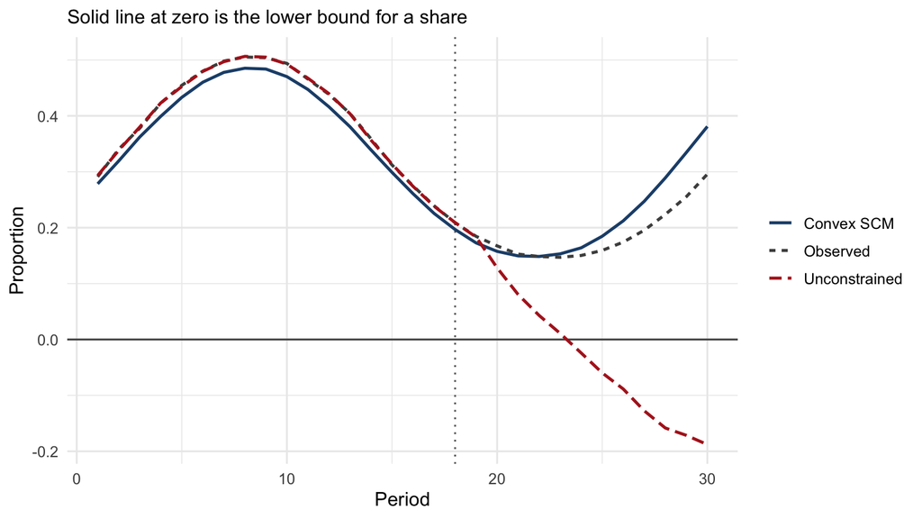

Figure 20: One draw where the unconstrained counterfactual leaves the valid range after the donors diverge. The convex synthetic control cannot.

```r
# First saved draw whose unconstrained counterfactual leaves [0, 1].
ex <- NULL
for (r in 1:200) {
  sub <- draws[draws$rep == r, ]
  P <- matrix(sub$share, nrow = Jp + 1, byrow = TRUE)
  D <- t(P[-1, ]); y <- P[1, ]
  uc <- lm(y[pre_p] ~ D[pre_p, ])
  cf_uc <- as.vector(cbind(1, D) %*% ifelse(is.na(coef(uc)), 0, coef(uc)))
  if (min(cf_uc) < 0) {
    ex <- list(y = y, uc = cf_uc, scm = as.vector(D %*% scm_weights(D, y, pre_p)))
    break
  }
}

data.frame(time = 1:TTp, Observed = ex$y,
           `Convex SCM` = ex$scm, `Unconstrained` = ex$uc,
           check.names = FALSE) |>
  pivot_longer(-time, names_to = "series", values_to = "share") |>
  ggplot(aes(time, share, colour = series, linetype = series)) +
  geom_hline(yintercept = 0, colour = "grey30") +
  geom_vline(xintercept = T0p, linetype = "dotted", colour = "grey40") +
  geom_line(linewidth = 0.9) +
  scale_colour_manual(values = c(Observed = "grey30",
                                 `Convex SCM` = PAL[["synth"]],
                                 Unconstrained = PAL[["treated"]])) +
  labs(x = "Period", y = "Proportion", colour = NULL, linetype = NULL,
       subtitle = "Solid line at zero is the lower bound for a share")
```

**Python**

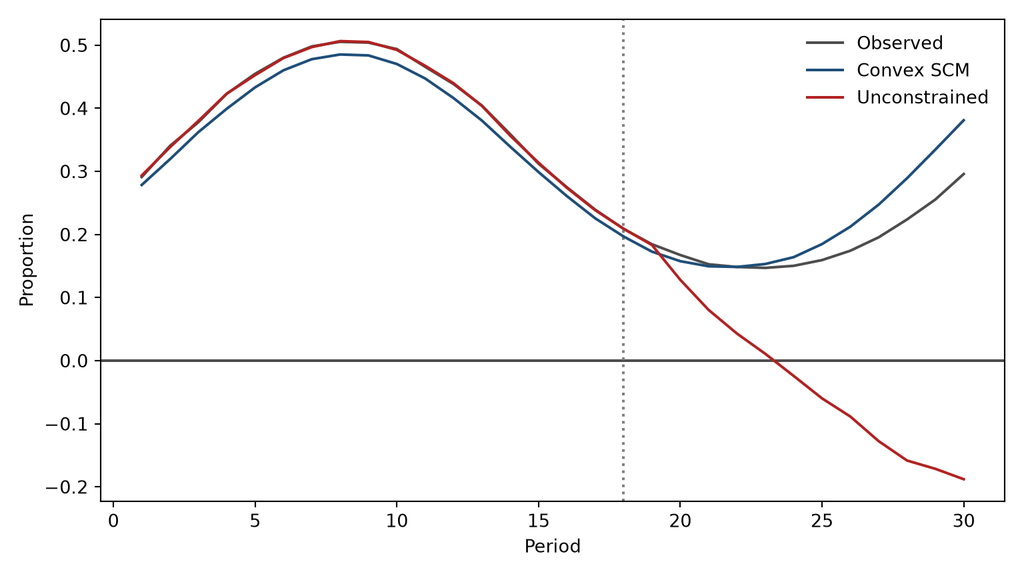

Figure 21

```python
ex = None
for r in range(1, 201):
    P = (draws[draws.rep == r]
         .pivot(index="unit", columns="time", values="share").values)
    D, y = P[1:].T, P[0]
    X = np.column_stack([np.ones(T0p), D[:T0p]])
    beta, *_ = np.linalg.lstsq(X, y[:T0p], rcond=None)
    cf_uc = np.column_stack([np.ones(TTp), D]) @ beta
    if cf_uc.min() < 0:
        ex = (y, D @ scm_weights(D, y), cf_uc)
        break

y, cf_scm, cf_uc = ex
t = range(1, TTp + 1)
fig, ax = plt.subplots(figsize=(8, 4.5))
ax.axhline(0, color="0.3")
ax.axvline(T0p, color="grey", linestyle=":")
ax.plot(t, y, color="0.3", label="Observed")
ax.plot(t, cf_scm, color="#1F4E79", label="Convex SCM")
ax.plot(t, cf_uc, color="#B22222", label="Unconstrained")
ax.set_xlabel("Period")
ax.set_ylabel("Proportion")
ax.legend(frameon=False)
plt.tight_layout()
plt.show()
```

**Stata**

```stata
import delimited "synthetic-control_files/data/sim_prop_draws.csv", clear
mata:
real colvector scm_w(real matrix Dm, real colvector y, real scalar T0,
                     real scalar iters, real scalar lr) {
    real scalar J, k, s
    real colvector w
    real matrix Dp
    Dp = Dm[1..T0,]; J = cols(Dm); w = J(J,1,1/J)
    for (k=1; k<=iters; k++) {
        w = w :- lr * (Dp' * (Dp*w :- y[1..T0]))
        w = w :* (w :> 0)
        s = colsum(w); if (s>0) w = w / s
    }
    return(w)
}
st_view(REP=.,.,"rep"); st_view(UN=.,.,"unit"); st_view(TM=.,.,"time"); st_view(SH=.,.,"share")
T0 = 18; res = J(30,4,.)
for (r=1; r<=200; r++) {
    idx = selectindex(REP:==r)
    un = UN[idx]; tm = TM[idx]; sh = SH[idx]
    P = J(11,30,.)
    for (i=1;i<=rows(idx);i++) P[un[i], tm[i]] = sh[i]
    y = P[1,]'; Dm = P[2..11,]'
    X = (J(T0,1,1), Dm[1..T0,]); b = invsym(X'X)*X'y[1..T0]
    cf_uc = (J(30,1,1), Dm)*b
    if (colmin(cf_uc) < 0) {
        cf_sc = Dm*scm_w(Dm, y, T0, 3000, 5e-3)
        res = ((1::30), y, cf_sc, cf_uc)
        break
    }
}
st_matrix("M", res)
end
clear
svmat M
rename (M1 M2 M3 M4) (time observed convex uncon)
twoway (line observed time, lcolor(gs6)) ///
       (line convex time, lcolor("31 78 121")) ///
       (line uncon time, lcolor("178 34 34")), ///
       yline(0) xline(18, lpattern(dot)) ///
       legend(order(1 "Observed" 2 "Convex SCM" 3 "Unconstrained")) ///
       xtitle("Period") ytitle("Proportion")
quietly graph export "sc_figs/fig-prop-stata.svg", replace width(1600)
```

```
(encoding automatically selected: ISO-8859-2)
(4 vars, 66,000 obs)

------------------------------------------------- mata (type end to exit) ------------------------------------------------------------------
: real colvector scm_w(real matrix Dm, real colvector y, real scalar T0,
>                      real scalar iters, real scalar lr) {
>     real scalar J, k, s
>     real colvector w
>     real matrix Dp
>     Dp = Dm[1..T0,]; J = cols(Dm); w = J(J,1,1/J)
>     for (k=1; k<=iters; k++) {
>         w = w :- lr * (Dp' * (Dp*w :- y[1..T0]))
>         w = w :* (w :> 0)
>         s = colsum(w); if (s>0) w = w / s
>     }
>     return(w)
> }

: st_view(REP=.,.,"rep"); st_view(UN=.,.,"unit"); st_view(TM=.,.,"time"); st_view(SH=.,.,"share")

: T0 = 18; res = J(30,4,.)

: for (r=1; r<=200; r++) {
>     idx = selectindex(REP:==r)
>     un = UN[idx]; tm = TM[idx]; sh = SH[idx]
>     P = J(11,30,.)
>     for (i=1;i<=rows(idx);i++) P[un[i], tm[i]] = sh[i]
>     y = P[1,]'; Dm = P[2..11,]'
>     X = (J(T0,1,1), Dm[1..T0,]); b = invsym(X'X)*X'y[1..T0]
>     cf_uc = (J(30,1,1), Dm)*b
>     if (colmin(cf_uc) < 0) {
>         cf_sc = Dm*scm_w(Dm, y, T0, 3000, 5e-3)
>         res = ((1::30), y, cf_sc, cf_uc)
>         break
>     }
> }

: st_matrix("M", res)

: end
--------------------------------------------------------------------------------------------------------------------------------------------


number of observations will be reset to 30
Press any key to continue, or Break to abort
Number of observations (_N) was 0, now 30.
```

[figure not shown]

## Choose the Scale Deliberately

| Approach | When it is useful | Main caution |
| --- | --- | --- |
| Raw proportion | Effects are naturally percentage points and the fit is sensible | Denominators may imply very different precision across observations |
| Logit-transformed proportion | Effects are more naturally multiplicative, or values crowd near 0 and 1 | Zeros and ones need a documented adjustment; back-transformation is nonlinear |
| Count or rate framing | You observe numerators and denominators and sampling precision matters | The estimator and interpretation may need to change, not just the outcome column |

The raw scale is usually the right place to start because it is interpretable: a gap of $0.04$ is four percentage points. Transform when it changes the fit, the modeling problem, or the substantive interpretation in a useful way, not because a textbook made proportions sound dangerous (Papke and Wooldridge 1996; Warton and Hui 2011).

## Denominators Are Part of the Data-Generating Process

A turnout rate based on 200 voters is not measured as precisely as one based on two million. A deforestation share from a tiny polygon is not the same object as one from a large landscape. If denominators vary sharply across units or time, say so and consider whether a count- or rate-aware analysis is warranted.

Report the numerator, denominator, range of denominators, occurrence of zeros and ones, outcome scale, and how any transformed estimate translates back into substantive units.

# A Practitioner’s Checklist

Work through this in order. Items one through four happen *before* you look at any post-treatment result.

**Design, before estimation**

1. **Define the treatment precisely.** What changed, for whom, and when did behavior plausibly begin to respond? Anticipation moves the effective date earlier than the statute.
2. **Fix the treatment date and justify it.** Enactment, implementation, and crediting dates are different dates.
3. **Build the donor pool from substantive knowledge.** Exclude units exposed to the same or similar interventions, units subject to spillover or displacement, and units whose measurement changed. Write the exclusion rule down before estimating.
4. **Fix the predictor set.** Decide what enters $X$ and on what pre-treatment window, aware that the full outcome path can crowd out covariates (Kaul et al. 2022).

**Fit and diagnose**

5. **Check pre-treatment fit first.** Plot it. Report pre-treatment RMSPE on the outcome’s own scale. If the paths do not align, stop and diagnose rather than proceeding.
6. **Inspect the donor weights.** Name the units carrying the comparison and say whether that composition is substantively sensible.
7. **Report predictor balance** against the raw donor average.
8. **Confirm the treated unit is inside donor support.** If it is not, say so, and consider augmentation (Ben-Michael, Feller, and Rothstein 2021) rather than pretending the convex fit succeeded.
9. **Check the outcome scale.** If the outcome is bounded, verify that fitted counterfactuals stay in range, especially with estimators that permit negative weights.

**Inference and robustness**

10. **Run placebo tests**, state the test statistic, state the pre-fit screening rule, and state whether the comparison is one- or two-sided.
11. **Consider design-appropriate intervals** rather than placebo p-values alone, such as conformal inference (Chernozhukov, Wüthrich, and Zhu 2021) or prediction intervals (Cattaneo, Feng, and Titiunik 2021).
12. **Run leave-one-out checks** on every high-weight donor.
13. **Vary the donor pool** across defensible exclusion rules and report whether conclusions move.

**Reporting**

14. **Show the path plot and the gap plot.** These are the evidence, not illustrations of it.
15. **Report the estimate on an interpretable scale**, in the outcome’s own units.
16. **Record software, package versions, optimization settings, and a random seed.** Synthetic control weights are not always unique (Klößner et al. 2018).
17. **Name the most credible failure mode** in the limitations. If a referee could break the design one way, say which way.

The goal is not to make the synthetic control look inevitable. It is to show that it is the most credible available counterfactual, while being candid about where that claim could break.

# FAQ

**When should I use SCM instead of difference-in-differences?**

Use SCM when one or a few important units receive treatment and no single comparison unit is credible. Use DiD when many treated and untreated units support a defensible parallel-trends argument. When both are plausible, show both; agreement is reassuring and disagreement is information.

**How many pre-treatment periods do I need?**

Enough to assess persistent fit. There is no universal threshold, because it depends on outcome volatility, the number of latent factors, and donor-pool size. Two or three periods can fit perfectly by accident, which is overfitting rather than validation.

**What if pre-treatment fit is poor?**

Diagnose before estimating effects. Reconsider the donor pool, outcome scale, treatment date, and predictor set, and check whether the treated unit lies outside donor support. Augmented SCM or a factor-model estimator may help. If fit remains poor, reporting that the design is not feasible is a legitimate result, as the poor-support simulation above shows.

**Can I include covariates?**

Yes, using pre-treatment covariates that predict the untreated outcome. Do not include post-treatment variables that treatment could have affected, and do not expect covariates to rescue a synthetic control that misses the pre-treatment outcome path.

**What if donors are affected by spillovers?**

Exclude them, define a less exposed donor pool, or show sensitivity analyses without them. A partly treated donor cannot cleanly reveal the untreated potential outcome.

**What if treatment timing varies across units?**

Classical `Synth` is not the right first tool. Use a counterfactual-imputation estimator such as `fect(..., method = "gsynth")`, and see the staggered-adoption literature for estimand choices (Ben-Michael, Feller, and Rothstein 2022).

**How do I interpret a placebo p-value?**

As a design-based rank comparison, not a conventional test. It says how unusual the treated unit’s gap statistic is among eligible fake-treated donors, and it is meaningful only when placebo units have reasonable pre-treatment fit and the donor pool is large enough.

# Cross-language translation

| Task | R | Python | Stata |
| --- | --- | --- | --- |
| Data wrangling | `dplyr`/`tidyr`, `read.csv` | `pandas` | `import delimited`, native |
| Plain regression / linear algebra | `lm`, matrix ops | `numpy`, `statsmodels` | `regress`, Mata |
| Classical SCM | `Synth::synth` | `pysyncon.Synth` | `synth` (Abadie) |
| Augmented SCM | `augsynth::augsynth` | `pysyncon.AugSynth` | `allsynth` (Wiltshire) |
| Generalized SCM / factor imputation | `fect::fect` | [`fect_python`](https://github.com/xuyiqing/fect_python) † | `fect` (Liu–Wang–Xu) |
| Figures | `ggplot2` | `matplotlib` | `twoway` |
| Simulated data | R generators (folded “Simulation design”) write CSVs | read the shared CSVs | read the shared CSVs |

# Reproducibility

**Installing `augsynth`.** The augmented synthetic control estimator is not on CRAN; it is distributed on GitHub (Ben-Michael, Feller, and Rothstein 2021). Install it once *before* rendering, using either of:

```r
pacman::p_load_gh("ebenmichael/augsynth")     # via pacman
remotes::install_github("ebenmichael/augsynth") # or via remotes
```

The setup chunk then only attaches it, with no network call, so the render stays deterministic. `augsynth` suggests `MCPanel` (also GitHub-only) for its matrix-completion option; this guide does not use that option, so a failed `MCPanel` build is harmless.

**Stata and Python engines.** `Statamarkdown` registers a `stata` knitr engine, which requires a local Stata installation and usually an explicit `engine.path`. `reticulate` provides the `python` engine; point it at an interpreter with `reticulate::use_python()` or `use_condaenv()`. Because a global `RETICULATE_PYTHON` in `~/.Rprofile` would override the guide’s own environment, the setup chunk clears it and binds the local `.venv`.

**Stata packages.** The Stata tabs use several user-written commands. Install them once with:

```stata
ssc install synth          // classical SCM (Abadie, Diamond, Hainmueller)
ssc install allsynth       // augmented / bias-corrected SCM (Wiltshire)
ssc install distinct       //   allsynth dependency
ssc install elasticregress //   allsynth ridge/lasso dependency
net install fect, from("https://raw.githubusercontent.com/xuyiqing/fect_stata/master/")
ssc install reghdfe        //   fect dependencies
ssc install ftools
ssc install _gwtmean
ssc install moremata
ssc install require
```

Statamarkdown does not auto-embed Stata graphs, so each Stata figure block ends with `graph export` to `sc_figs/` followed by an image include. Intermediate `.dta` handoffs between Stata blocks are written to `synthetic-control_files/stata/` (created by the setup chunk) rather than the project root.

**Python packages.** The `.venv` holds `numpy`, `pandas`, `scipy`, `statsmodels`, `matplotlib`, and `pysyncon`. The generalized-SCM (`fect`) Python tabs use a compact native NumPy implementation rather than `fect_python`, whose `rpy2` bridge conflicts with this environment.

**Data.** The datasets are cached as CSVs under `synthetic-control_files/data/`, exported from `tidysynth` and `fect`, with full provenance in that folder’s `PROVENANCE.md` and in the footnotes where each dataset is introduced. Simulated panels are generated once in R (the folded “Simulation design” blocks) and written there so all three languages read identical inputs.

The exact package versions used to render this document:

**R**

**Session info**

```r
if (requireNamespace("sessioninfo", quietly = TRUE)) {
} else {
}
```

[output not shown]

**Python**

```python
import sys, numpy, pandas, scipy, matplotlib, pysyncon
print("Python", sys.version.split()[0])
```

```
Python 3.12.2
```

```python
for m in (numpy, pandas, scipy, matplotlib, pysyncon):
    print(f"{m.__name__:12s} {m.__version__}")
```

```
numpy        2.5.2
pandas       3.0.5
scipy        1.18.0
matplotlib   3.11.1
pysyncon     1.5.1
```

**Stata**

```stata
about
```

```
StataNow/MP 19.5 for Mac (Apple Silicon)
Revision 03 Jun 2026
Copyright 1985-2025 StataCorp LLC

Total physical memory: 32.01 GB

Stata license: Single-user 2-core , expiring  1 Jul 2027
Serial number: 501909374535
  Licensed to: Ellsworth, Ted
               Yale University
```

# References

Abadie, Alberto. 2021. “Using Synthetic Controls: Feasibility, Data Requirements, and Methodological Aspects.” *Journal of Economic Literature* 59 (2): 391–425. https://doi.org/10.1257/jel.20191450.

Abadie, Alberto, Alexis Diamond, and Jens Hainmueller. 2010. “Synthetic Control Methods for Comparative Case Studies: Estimating the Effect of California’s Tobacco Control Program.” *Journal of the American Statistical Association* 105 (490): 493–505. https://doi.org/10.1198/jasa.2009.ap08746.

———. 2015. “Comparative Politics and the Synthetic Control Method.” *American Journal of Political Science* 59 (2): 495–510. https://doi.org/10.1111/ajps.12116.

Abadie, Alberto, and Javier Gardeazabal. 2003. “The Economic Costs of Conflict: A Case Study of the Basque Country.” *American Economic Review* 93 (1): 113–32. https://doi.org/10.1257/000282803321455188.

Ben-Michael, Eli, Avi Feller, and Jesse Rothstein. 2021. “The Augmented Synthetic Control Method.” *Journal of the American Statistical Association* 116 (536): 1789–1803. https://doi.org/10.1080/01621459.2021.1929245.

———. 2022. “Synthetic Controls with Staggered Adoption.” *Journal of the Royal Statistical Society Series B: Statistical Methodology* 84 (2): 351–81. https://doi.org/10.1111/rssb.12448.

Born, Benjamin, Gernot J. Müller, Moritz Schularick, and Petr Sedláček. 2019. “The Costs of Economic Nationalism: Evidence from the Brexit Experiment.” *The Economic Journal* 129 (623): 2722–44. https://doi.org/10.1093/ej/uez020.

Cattaneo, Matias D., Yingjie Feng, and Rocio Titiunik. 2021. “Prediction Intervals for Synthetic Control Methods.” *Journal of the American Statistical Association* 116 (536): 1865–80. https://doi.org/10.1080/01621459.2021.1979561.

Chernozhukov, Victor, Kaspar Wüthrich, and Yinchu Zhu. 2021. “An Exact and Robust Conformal Inference Method for Counterfactual and Synthetic Controls.” *Journal of the American Statistical Association* 116 (536): 1849–64. https://doi.org/10.1080/01621459.2021.1920957.

Dunford, Eric. 2025. *tidysynth: A Tidy Implementation of the Synthetic Control Method (R package version 0.2.1)*. Comprehensive R Archive Network. https://doi.org/10.32614/CRAN.package.tidysynth.

Ferman, Bruno, Cristine Pinto, and Vitor Possebom. 2020. “Cherry Picking with Synthetic Controls.” *Journal of Policy Analysis and Management* 39 (2): 510–32. https://doi.org/10.1002/pam.22206.

Hainmueller, Jens, and Alexis Diamond. 2026. *Synth: Synthetic Control Group Method for Comparative Case Studies (R package version 1.1-10)*. Comprehensive R Archive Network. https://doi.org/10.32614/CRAN.package.Synth.

Kaul, Ashok, Stefan Klößner, Gregor Pfeifer, and Manuel Schieler. 2022. “Standard Synthetic Control Methods: The Case of Using All Preintervention Outcomes Together with Covariates.” *Journal of Business & Economic Statistics* 40 (3): 1362–76. https://doi.org/10.1080/07350015.2021.1930012.

Klößner, Stefan, Ashok Kaul, Gregor Pfeifer, and Manuel Schieler. 2018. “Comparative Politics and the Synthetic Control Method Revisited: A Note on Abadie et al. (2015).” *Swiss Journal of Economics and Statistics* 154: 11. https://doi.org/10.1186/s41937-017-0004-9.

Papke, Leslie E., and Jeffrey M. Wooldridge. 1996. “Econometric Methods for Fractional Response Variables with an Application to 401(k) Plan Participation Rates.” *Journal of Applied Econometrics* 11 (6): 619–32. https://doi.org/10.1002/(SICI)1099-1255(199611)11:6<619::AID-JAE418>3.0.CO;2-1.

Warton, David I., and Francis K. C. Hui. 2011. “The Arcsine Is Asinine: The Analysis of Proportions in Ecology.” *Ecology* 92 (1): 3–10. https://doi.org/10.1890/10-0340.1.

West, Thales A. P., Sven Wunder, Erin O. Sills, Jan Börner, Sami W. Rifai, Alexandra N. Neidermeier, Gabriel P. Frey, and Andreas Kontoleon. 2023. “Action Needed to Make Carbon Offsets from Forest Conservation Work for Climate Change Mitigation.” *Science* 381 (6660): 873–77. https://doi.org/10.1126/science.ade3535.

Xu, Yiqing. 2017. “Generalized Synthetic Control Method: Causal Inference with Interactive Fixed Effects Models.” *Political Analysis* 25 (1): 57–76. https://doi.org/10.1017/pan.2016.2.

Xu, Yiqing, Licheng Liu, Ye Wang, Ziyi Liu, Shijian Liu, Tianzhu Qin, Jinwen Wu, and Rivka Lipkovitz. 2026. *fect: Fixed Effects Counterfactual Estimators – User Manual (v2.4.5)*. https://yiqingxu.org/packages/fect/.

## Footnotes

[^1]: This guide reads a cached copy, `synthetic-control_files/data/smoking.csv`, exported from `tidysynth::smoking` (v0.2.1); see `PROVENANCE.md` in that folder for full provenance.
[^2]: Read here as a cached copy, `synthetic-control_files/data/simgsynth.csv`, exported from `fect::simgsynth` (v2.4.5); see `PROVENANCE.md`.
[^3]: Read here as a cached copy, `synthetic-control_files/data/turnout.csv`, exported from `fect::turnout` (v2.4.5); see `PROVENANCE.md`.